# Devoir 2 - Régression Logisitique (GLM)

### (1.1.12) Ext_Qualite

Par la suite, nous allons procéder au regroupement de la variable Ext_Qualite similairement à la méthode utilisée pour combiner les modalités de la variable Zone, c’est-à-dire à l’aide des boîtes à moustaches et du test de Wald.

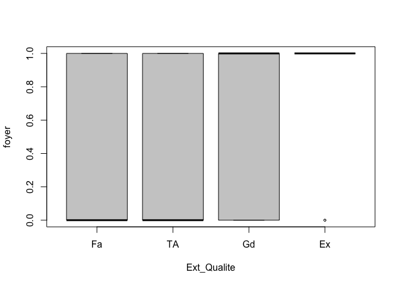

```r
A = with(data = DF, aggregate(foyer,by=list(Ext_Qualite),FUN=mean))
A = A[order(A$x),]
L = as.character(A$Group.1)
DF$Ext_Qualite= factor(DF$Ext_Qualite, level=L)
with(data = DF, boxplot(foyer~Ext_Qualite,cex=.5,col=grey(.8)))
```

```r
reg_Ext_Qualite= glm(foyer~Ext_Qualite,data = DF,family = binomial(link = "logit"))
summary(reg_Ext_Qualite)
```

```
##
## Call:
## glm(formula = foyer ~ Ext_Qualite, family = binomial(link = "logit"),
##     data = DF)
##
## Deviance Residuals:
##     Min       1Q   Median       3Q      Max
## -2.4864  -0.9955   0.3050   0.8683   1.4823
##
## Coefficients:
##               Estimate Std. Error z value Pr(>|z|)
## (Intercept)    -0.6931     0.8660  -0.800   0.4235
## Ext_QualiteTA   0.2489     0.8714   0.286   0.7752
## Ext_QualiteGd   1.4744     0.8770   1.681   0.0927 .
## Ext_QualiteEx   3.7377     1.3407   2.788   0.0053 **
## ---
## Signif. codes:  0 '***' 0.001 '**' 0.01 '*' 0.05 '.' 0.1 ' ' 1
##
## (Dispersion parameter for binomial family taken to be 1)
##
##     Null deviance: 1002.18  on 722  degrees of freedom
## Residual deviance:  923.15  on 719  degrees of freedom
## AIC: 931.15
##
## Number of Fisher Scoring iterations: 5
```

```r
library(car)
linearHypothesis(reg_Ext_Qualite, c("Ext_QualiteTA = 0"))
```

```
## Linear hypothesis test
##
## Hypothesis:
## Ext_QualiteTA = 0
##
## Model 1: restricted model
## Model 2: foyer ~ Ext_Qualite
##
##   Res.Df Df  Chisq Pr(>Chisq)
## 1    720
## 2    719  1 0.0816     0.7752
```

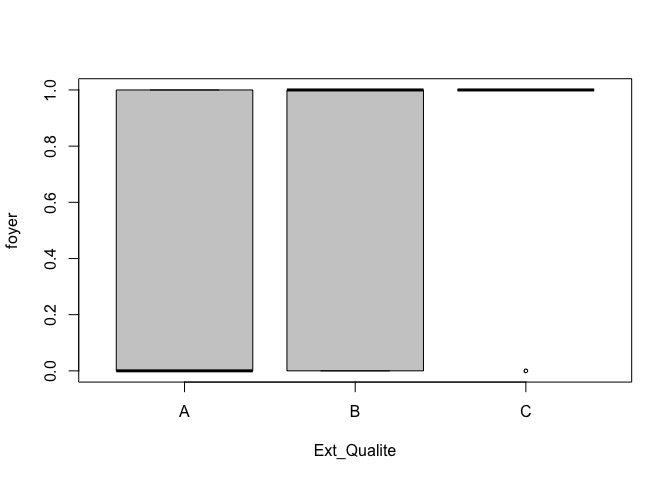

```r
levels(DF$Ext_Qualite) = c(rep("A",2),"B","C")
DF$Ext_Qualite = relevel(DF$Ext_Qualite,"A")
with(data = DF, boxplot(foyer~Ext_Qualite,cex=.5,col=grey(.8)))
```

```r
reg_Ext_Qualite= glm(foyer~Ext_Qualite,data = DF,family = binomial(link = "logit"))
summary(reg_Ext_Qualite)
```

```
##
## Call:
## glm(formula = foyer ~ Ext_Qualite, family = binomial(link = "logit"),
##     data = DF)
##
## Deviance Residuals:
##     Min       1Q   Median       3Q      Max
## -2.4864  -0.9942   0.3050   0.8683   1.3723
##
## Coefficients:
##              Estimate Std. Error z value Pr(>|z|)
## (Intercept)   -0.4474     0.0957  -4.675 2.94e-06 ***
## Ext_QualiteB   1.2287     0.1683   7.298 2.91e-13 ***
## Ext_QualiteC   3.4919     1.0279   3.397 0.000681 ***
## ---
## Signif. codes:  0 '***' 0.001 '**' 0.01 '*' 0.05 '.' 0.1 ' ' 1
##
## (Dispersion parameter for binomial family taken to be 1)
##
##     Null deviance: 1002.18  on 722  degrees of freedom
## Residual deviance:  923.23  on 720  degrees of freedom
## AIC: 929.23
##
## Number of Fisher Scoring iterations: 5
```

Enfin, nous avons réussi à réduire le nombre de modalités pour la variable Ext_Qualite et nous nous retrouvons avec les trois sous-groupes suivants : Ext_QualiteA, Ext_QualiteB, Ext_QualiteC. Par ailleurs, nous constatons qu’elle s’avère significative dans la régression logistique. De ce fait, cette variable est très intéressante en raison de sa faible p-value et nous allons la retenir pour la construction du modèle.

Où

Ext_QualiteA = {Fa, TA}

Ext_QualiteB = {Gd}

Ext_QualiteC = {Ex}

### (1.1.13) Ext_Condition

Par la suite, nous allons procéder au regroupement de la variable Ext_Condition similairement à la méthode utilisée pour combiner les modalités de la variable Zone, c’est-à-dire à l’aide des boîtes à moustaches et du test de Wald.

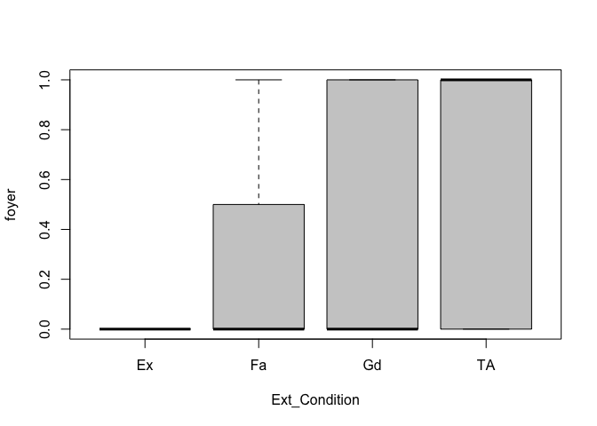

```r
A = with(data = DF, aggregate(foyer,by=list(Ext_Condition),FUN=mean))
A = A[order(A$x),]
L = as.character(A$Group.1)
DF$Ext_Condition= factor(DF$Ext_Condition, level=L)
with(data = DF, boxplot(foyer~Ext_Condition,cex=.5,col=grey(.8)))
```

```r
reg_Ext_Condition= glm(foyer~Ext_Condition,data = DF,family = binomial(link = "logit"))
summary(reg_Ext_Condition)
```

```
##
## Call:
## glm(formula = foyer ~ Ext_Condition, family = binomial(link = "logit"),
##     data = DF)
##
## Deviance Residuals:
##    Min      1Q  Median      3Q     Max
## -1.213  -1.213   1.143   1.143   1.665
##
## Coefficients:
##                 Estimate Std. Error z value Pr(>|z|)
## (Intercept)       -13.57     535.41  -0.025    0.980
## Ext_ConditionFa    12.47     535.41   0.023    0.981
## Ext_ConditionGd    13.39     535.41   0.025    0.980
## Ext_ConditionTA    13.65     535.41   0.025    0.980
##
## (Dispersion parameter for binomial family taken to be 1)
##
##     Null deviance: 1002.18  on 722  degrees of freedom
## Residual deviance:  994.09  on 719  degrees of freedom
## AIC: 1002.1
##
## Number of Fisher Scoring iterations: 12
```

```r
library(car)
linearHypothesis(reg_Ext_Condition, c("Ext_ConditionFa = 0",
                                    "Ext_ConditionGd = 0"))
```

```
## Linear hypothesis test
##
## Hypothesis:
## Ext_ConditionFa = 0
## Ext_ConditionGd = 0
##
## Model 1: restricted model
## Model 2: foyer ~ Ext_Condition
##
##   Res.Df Df  Chisq Pr(>Chisq)
## 1    721
## 2    719  2 2.6496     0.2659
```

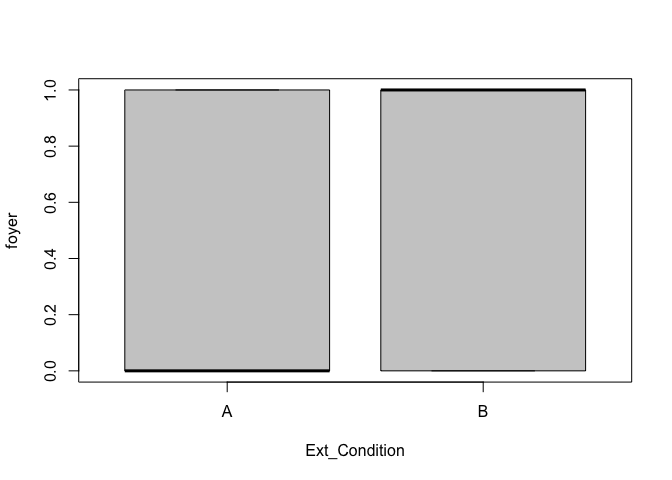

```r
levels(DF$Ext_Condition) = c(rep("A",3),"B")
DF$Ext_Qualite = relevel(DF$Ext_Condition,"A")
with(data = DF, boxplot(foyer~Ext_Condition,cex=.5,col=grey(.8)))
```

```r
reg_Ext_Condition= glm(foyer~Ext_Condition,data = DF,family = binomial(link = "logit"))
summary(reg_Ext_Condition)
```

```
##
## Call:
## glm(formula = foyer ~ Ext_Condition, family = binomial(link = "logit"),
##     data = DF)
##
## Deviance Residuals:
##    Min      1Q  Median      3Q     Max
## -1.213  -1.213   1.143   1.143   1.342
##
## Coefficients:
##                Estimate Std. Error z value Pr(>|z|)
## (Intercept)     -0.3781     0.2134  -1.772   0.0765 .
## Ext_ConditionB   0.4604     0.2278   2.021   0.0433 *
## ---
## Signif. codes:  0 '***' 0.001 '**' 0.01 '*' 0.05 '.' 0.1 ' ' 1
##
## (Dispersion parameter for binomial family taken to be 1)
##
##     Null deviance: 1002.18  on 722  degrees of freedom
## Residual deviance:  998.03  on 721  degrees of freedom
## AIC: 1002
##
## Number of Fisher Scoring iterations: 3
```

Enfin, nous avons réussi à réduire le nombre de modalités pour la variable Ext_Condition et nous nous retrouvons avec les deux sous-groupes suivants : Ext_ConditionA, Ext_ConditionB. Par ailleurs, nous constatons qu’elle s’avère significative dans la régression logistique. De ce fait, cette variable est intéressante en raison de sa faible p-value et nous allons la retenir pour la construction du modèle.

Où

Ext_ConditionA = {Ex, Fa, Gd}

Ext_ConditionB = {TA}

### (1.1.14) Foundation

Encore une fois, nous allons procéder au regroupement de la variable Foundation similairement à la méthode utilisée pour combiner les modalités de la variable Zone, c’est-à-dire à l’aide des boîtes à moustaches et du test de Wald.

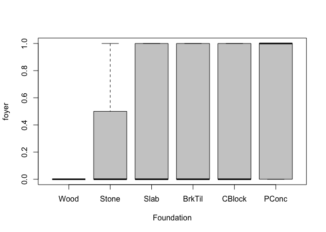

```r
A = with(data = DF, aggregate(foyer,by=list(Foundation),FUN=mean))
A = A[order(A$x),]
L = as.character(A$Group.1)
DF$Foundation= factor(DF$Foundation, level=L)
with(data = DF, boxplot(foyer~Foundation,cex=.5,col=grey(.8)))
```

```r
reg_Foundation= glm(foyer~Foundation,data = DF,family = binomial(link = "logit"))
summary(reg_Foundation)
```

```
##
## Call:
## glm(formula = foyer ~ Foundation, family = binomial(link = "logit"),
##     data = DF)
##
## Deviance Residuals:
##     Min       1Q   Median       3Q      Max
## -1.4051  -1.0731   0.9656   0.9656   1.6651
##
## Coefficients:
##                  Estimate Std. Error z value Pr(>|z|)
## (Intercept)        -13.57     535.41  -0.025    0.980
## FoundationStone     12.47     535.41   0.023    0.981
## FoundationSlab      12.87     535.41   0.024    0.981
## FoundationBrkTil    12.91     535.41   0.024    0.981
## FoundationCBlock    13.32     535.41   0.025    0.980
## FoundationPConc     14.09     535.41   0.026    0.979
##
## (Dispersion parameter for binomial family taken to be 1)
##
##     Null deviance: 1002.18  on 722  degrees of freedom
## Residual deviance:  964.97  on 717  degrees of freedom
## AIC: 976.97
##
## Number of Fisher Scoring iterations: 12
```

```r
library(car)
linearHypothesis(reg_Foundation, c("FoundationStone = 0",
                             "FoundationSlab = 0",
                             "FoundationBrkTil = 0",
                             "FoundationCBlock = 0"))
```

```
## Linear hypothesis test
##
## Hypothesis:
## FoundationStone = 0
## FoundationSlab = 0
## FoundationBrkTil = 0
## FoundationCBlock = 0
##
## Model 1: restricted model
## Model 2: foyer ~ Foundation
##
##   Res.Df Df  Chisq Pr(>Chisq)
## 1    721
## 2    717  4 3.1502      0.533
```

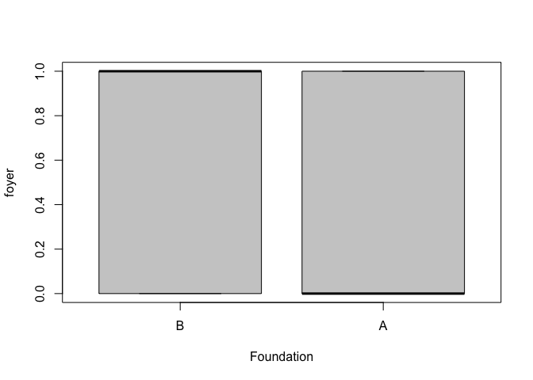

```r
levels(DF$Foundation) = c(rep("A",5),"B")
DF$Foundation = relevel(DF$Foundation,"B")
with(data = DF, boxplot(foyer~Foundation,cex=.5,col=grey(.8)))
```

```r
reg_Foundation= glm(foyer~Foundation,data = DF,family = binomial(link = "logit"))
summary(reg_Foundation)
```

```
##
## Call:
## glm(formula = foyer ~ Foundation, family = binomial(link = "logit"),
##     data = DF)
##
## Deviance Residuals:
##     Min       1Q   Median       3Q      Max
## -1.4051  -1.0326   0.9656   0.9656   1.3295
##
## Coefficients:
##             Estimate Std. Error z value Pr(>|z|)
## (Intercept)   0.5210     0.1167   4.464 8.04e-06 ***
## FoundationA  -0.8718     0.1540  -5.662 1.50e-08 ***
## ---
## Signif. codes:  0 '***' 0.001 '**' 0.01 '*' 0.05 '.' 0.1 ' ' 1
##
## (Dispersion parameter for binomial family taken to be 1)
##
##     Null deviance: 1002.18  on 722  degrees of freedom
## Residual deviance:  969.29  on 721  degrees of freedom
## AIC: 973.29
##
## Number of Fisher Scoring iterations: 4
```

Enfin, nous avons réussi à réduire le nombre de modalités pour la variable Fondation et nous nous retrouvons avec les deux sous-groupes suivants : FondationA, FondationB. Par ailleurs, nous constatons qu’elle s’avère significative dans la régression logistique. De ce fait, cette variable est très intéressante en raison de sa faible p-value et nous allons la retenir pour la construction du modèle.

Où

Fondation A = {Wood, Stone, Slab, BrkTil, CBlock}

FondationB = {PConc}

### (1.1.15) Chauffage

Par la suite, nous allons procéder au regroupement de la variable Chauffage similairement à la méthode utilisée pour combiner les modalités de la variable Zone, c’est-à-dire à l’aide des boîtes à moustaches et du test de Wald.

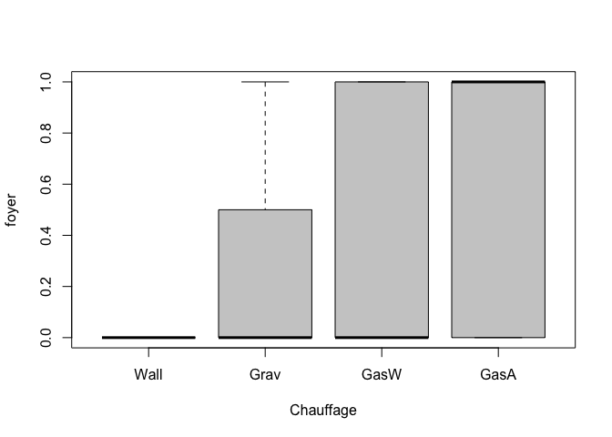

```r
A = with(data = DF, aggregate(foyer,by=list(Chauffage),FUN=mean))
A = A[order(A$x),]
L = as.character(A$Group.1)
DF$Chauffage= factor(DF$Chauffage, level=L)
with(data = DF, boxplot(foyer~Chauffage,cex=.5,col=grey(.8)))
```

```r
reg_Chauffage= glm(foyer~Chauffage,data = DF,family = binomial(link = "logit"))
summary(reg_Chauffage)
```

```
##
## Call:
## glm(formula = foyer ~ Chauffage, family = binomial(link = "logit"),
##     data = DF)
##
## Deviance Residuals:
##    Min      1Q  Median      3Q     Max
## -1.198  -1.198   1.157   1.157   1.665
##
## Coefficients:
##               Estimate Std. Error z value Pr(>|z|)
## (Intercept)     -14.57     509.65  -0.029    0.977
## ChauffageGrav    13.47     509.65   0.026    0.979
## ChauffageGasW    14.01     509.65   0.027    0.978
## ChauffageGasA    14.61     509.65   0.029    0.977
##
## (Dispersion parameter for binomial family taken to be 1)
##
##     Null deviance: 1002.18  on 722  degrees of freedom
## Residual deviance:  995.85  on 719  degrees of freedom
## AIC: 1003.8
##
## Number of Fisher Scoring iterations: 13
```

```r
library(car)
linearHypothesis(reg_Chauffage, c("ChauffageGrav  = 0",
                             "ChauffageGasW= 0"))
```

```
## Linear hypothesis test
##
## Hypothesis:
## ChauffageGrav = 0
## ChauffageGasW = 0
##
## Model 1: restricted model
## Model 2: foyer ~ Chauffage
##
##   Res.Df Df Chisq Pr(>Chisq)
## 1    721
## 2    719  2 0.169      0.919
```

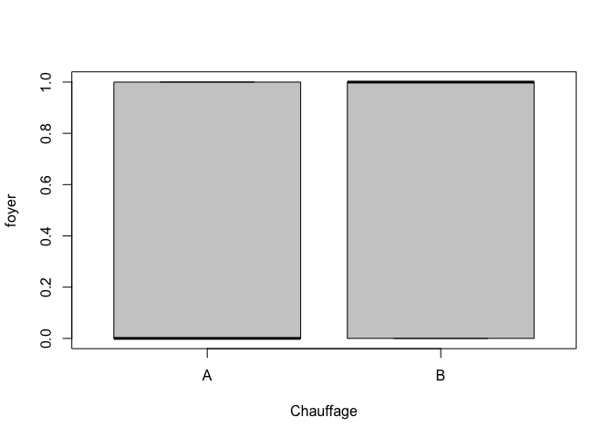

```r
levels(DF$Chauffage) = c(rep("A",3),"B")
DF$Chauffage = relevel(DF$Chauffage,"A")
with(data = DF, boxplot(foyer~Chauffage,cex=.5,col=grey(.8)))
```

```r
reg_Chauffage= glm(foyer~Chauffage,data = DF,family = binomial(link = "logit"))
summary(reg_Chauffage)
```

```
##
## Call:
## glm(formula = foyer ~ Chauffage, family = binomial(link = "logit"),
##     data = DF)
##
## Deviance Residuals:
##    Min      1Q  Median      3Q     Max
## -1.198  -1.198   1.157   1.157   1.601
##
## Coefficients:
##             Estimate Std. Error z value Pr(>|z|)
## (Intercept)  -0.9555     0.5262  -1.816   0.0694 .
## ChauffageB    1.0037     0.5316   1.888   0.0590 .
## ---
## Signif. codes:  0 '***' 0.001 '**' 0.01 '*' 0.05 '.' 0.1 ' ' 1
##
## (Dispersion parameter for binomial family taken to be 1)
##
##     Null deviance: 1002.2  on 722  degrees of freedom
## Residual deviance:  998.2  on 721  degrees of freedom
## AIC: 1002.2
##
## Number of Fisher Scoring iterations: 4
```

Ainsi, nous avons réussi à réduire le nombre de modalités pour la variable Chauffage et nous nous retrouvons avec les deux sous-groupes suivants : ChauffageA, ChauffageB. Par ailleurs, nous constatons la variable Chauffage est n’est pas trop intéressante en raison de sa p-value légèrement élevée. Cependant, nous avons néanmoins décidé de la retenir au cas où elle pourrait soudainement devenir pertinente lorsqu’elle est combinée avec d’autres variables explicatives lors de la construction du modèle.

Où

ChauffageA = {Wall, Grav, GasW}

ChauffageB = {GasA}

### (1.1.16) Chauff_Qualite

Ensuite, nous allons procéder au regroupement de la variable Chauff_Qualite similairement à la méthode utilisée pour combiner les modalités de la variable Zone, c’est-à-dire à l’aide des boîtes à moustaches et du test de Wald.

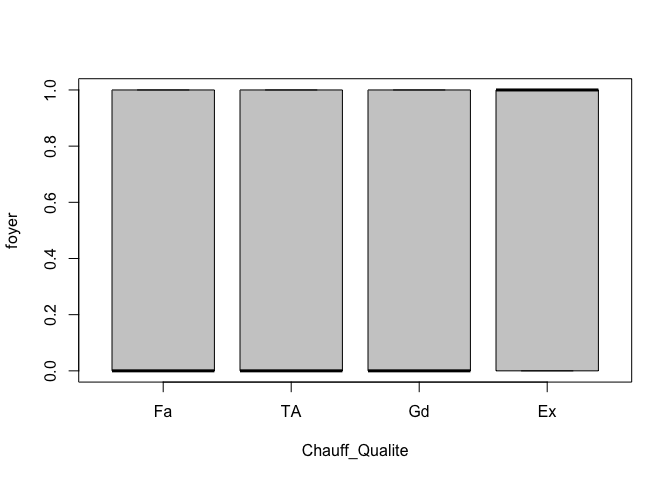

```r
A = with(data = DF, aggregate(foyer,by=list(Chauff_Qualite),FUN=mean))
A = A[order(A$x),]
L = as.character(A$Group.1)
DF$Chauff_Qualite= factor(DF$Chauff_Qualite, level=L)
with(data = DF, boxplot(foyer~Chauff_Qualite,cex=.5,col=grey(.8)))
```

```r
reg_Chauff_Qualite= glm(foyer~Chauff_Qualite,data = DF,family = binomial(link = "logit"))
summary(reg_Chauff_Qualite)
```

```
##
## Call:
## glm(formula = foyer ~ Chauff_Qualite, family = binomial(link = "logit"),
##     data = DF)
##
## Deviance Residuals:
##    Min      1Q  Median      3Q     Max
## -1.332  -1.072   1.030   1.030   1.413
##
## Coefficients:
##                  Estimate Std. Error z value Pr(>|z|)
## (Intercept)       -0.5390     0.4756  -1.133   0.2571
## Chauff_QualiteTA   0.2513     0.4950   0.508   0.6116
## Chauff_QualiteGd   0.2858     0.5063   0.565   0.5724
## Chauff_QualiteEx   0.8950     0.4878   1.835   0.0665 .
## ---
## Signif. codes:  0 '***' 0.001 '**' 0.01 '*' 0.05 '.' 0.1 ' ' 1
##
## (Dispersion parameter for binomial family taken to be 1)
##
##     Null deviance: 1002.18  on 722  degrees of freedom
## Residual deviance:  983.39  on 719  degrees of freedom
## AIC: 991.39
##
## Number of Fisher Scoring iterations: 4
```

```r
library(car)
linearHypothesis(reg_Chauff_Qualite, c("Chauff_QualiteTA = 0",
                             "Chauff_QualiteGd = 0"))
```

```
## Linear hypothesis test
##
## Hypothesis:
## Chauff_QualiteTA = 0
## Chauff_QualiteGd = 0
##
## Model 1: restricted model
## Model 2: foyer ~ Chauff_Qualite
##
##   Res.Df Df  Chisq Pr(>Chisq)
## 1    721
## 2    719  2 0.3187     0.8527
```

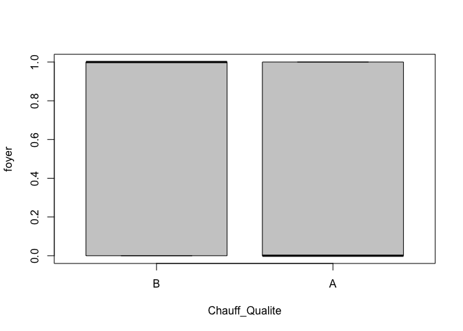

```r
levels(DF$Chauff_Qualite) = c(rep("A",3),"B")
DF$Chauff_Qualite = relevel(DF$Chauff_Qualite,"B")
with(data = DF, boxplot(foyer~Chauff_Qualite,cex=.5,col=grey(.8)))
```

```r
reg_Chauff_Qualite= glm(foyer~Chauff_Qualite,data = DF,family = binomial(link = "logit"))
summary(reg_Chauff_Qualite)
```

```
##
## Call:
## glm(formula = foyer ~ Chauff_Qualite, family = binomial(link = "logit"),
##     data = DF)
##
## Deviance Residuals:
##    Min      1Q  Median      3Q     Max
## -1.332  -1.058   1.030   1.030   1.302
##
## Coefficients:
##                 Estimate Std. Error z value Pr(>|z|)
## (Intercept)       0.3560     0.1083   3.287  0.00101 **
## Chauff_QualiteA  -0.6437     0.1508  -4.269 1.96e-05 ***
## ---
## Signif. codes:  0 '***' 0.001 '**' 0.01 '*' 0.05 '.' 0.1 ' ' 1
##
## (Dispersion parameter for binomial family taken to be 1)
##
##     Null deviance: 1002.18  on 722  degrees of freedom
## Residual deviance:  983.72  on 721  degrees of freedom
## AIC: 987.72
##
## Number of Fisher Scoring iterations: 4
```

Enfin, nous avons réussi à réduire le nombre de modalités pour la variable Chauff_Qualite et nous nous retrouvons avec les deux sous-groupes suivants : Chauff_QualiteA, Chauff_QualiteB. Par ailleurs, nous constatons qu’elle s’avère significative dans la régression logistique. De ce fait, cette variable est très intéressante en raison de sa faible p-value et nous allons la retenir pour la construction du modèle.

Où

Chauff_Qualite A = {Fa, TA, Gd}

Chaff_QualiteB = {Ex}

### (1.1.17) Electricite

Par la suite, nous allons procéder au regroupement de la variable Electricite similairement à la méthode utilisée pour combiner les modalités de la variable Zone, c’est-à-dire à l’aide des boîtes à moustaches et du test de Wald.

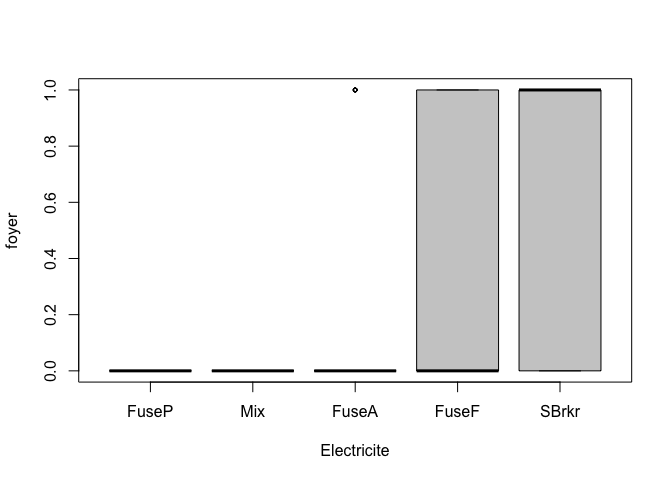

```r
A = with(data = DF, aggregate(foyer,by=list(Electricite),FUN=mean))
A = A[order(A$x),]
L = as.character(A$Group.1)
DF$Electricite= factor(DF$Electricite, level=L)
with(data = DF, boxplot(foyer~Electricite,cex=.5,col=grey(.8)))
```

```r
reg_Electricite = glm(foyer~Electricite,data = DF,family = binomial(link = "logit"))
summary(reg_Electricite)
```

```
##
## Call:
## glm(formula = foyer ~ Electricite, family = binomial(link = "logit"),
##     data = DF)
##
## Deviance Residuals:
##    Min      1Q  Median      3Q     Max
## -1.228  -1.228   1.128   1.128   1.708
##
## Coefficients:
##                    Estimate Std. Error z value Pr(>|z|)
## (Intercept)      -1.457e+01  6.242e+02  -0.023    0.981
## ElectriciteMix    1.349e-08  1.081e+03   0.000    1.000
## ElectriciteFuseA  1.337e+01  6.242e+02   0.021    0.983
## ElectriciteFuseF  1.398e+01  6.242e+02   0.022    0.982
## ElectriciteSBrkr  1.468e+01  6.242e+02   0.024    0.981
##
## (Dispersion parameter for binomial family taken to be 1)
##
##     Null deviance: 1002.18  on 722  degrees of freedom
## Residual deviance:  981.71  on 718  degrees of freedom
## AIC: 991.71
##
## Number of Fisher Scoring iterations: 13
```

```r
library(car)
linearHypothesis(reg_Electricite, c("ElectriciteMix = 0",
                             "ElectriciteFuseA = 0",
                             "ElectriciteFuseF = 0"))
```

```
## Linear hypothesis test
##
## Hypothesis:
## ElectriciteMix = 0
## ElectriciteFuseA = 0
## ElectriciteFuseF = 0
##
## Model 1: restricted model
## Model 2: foyer ~ Electricite
##
##   Res.Df Df Chisq Pr(>Chisq)
## 1    721
## 2    718  3 0.833     0.8416
```

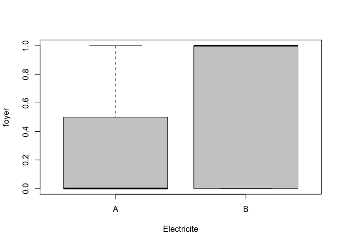

```r
levels(DF$Electricite) = c(rep("A",4),"B")
DF$Electricite = relevel(DF$Electricite,"A")
with(data = DF, boxplot(foyer~Electricite,cex=.5,col=grey(.8)))
```

```r
reg_Electricite = glm(foyer~Electricite,data = DF,family = binomial(link = "logit"))
summary(reg_Electricite)
```

```
##
## Call:
## glm(formula = foyer ~ Electricite, family = binomial(link = "logit"),
##     data = DF)
##
## Deviance Residuals:
##    Min      1Q  Median      3Q     Max
## -1.228  -1.228   1.128   1.128   1.665
##
## Coefficients:
##              Estimate Std. Error z value Pr(>|z|)
## (Intercept)   -1.0986     0.2981  -3.685 0.000229 ***
## ElectriciteB   1.2164     0.3081   3.948 7.89e-05 ***
## ---
## Signif. codes:  0 '***' 0.001 '**' 0.01 '*' 0.05 '.' 0.1 ' ' 1
##
## (Dispersion parameter for binomial family taken to be 1)
##
##     Null deviance: 1002.2  on 722  degrees of freedom
## Residual deviance:  984.3  on 721  degrees of freedom
## AIC: 988.3
##
## Number of Fisher Scoring iterations: 4
```

Enfin, nous avons réussi à réduire le nombre de modalités pour la variable Electricite et nous nous retrouvons avec les deux sous-groupes suivants : ElectriciteA, ElectriciteB. Par ailleurs, nous constatons qu’elle s’avère significative dans la régression logistique. De ce fait, cette variable est très intéressante en raison de sa faible p-value et nous allons la retenir pour la construction du modèle.

Où

ElectriciteA = {FuseP, Mix, FuseA, FuseF}

ElectriciteB = {SBrkr}

### (1.1.18) Cuisine_Qualite

Par la suite, nous allons procéder au regroupement de la variable Cuisine_Qualite similairement à la méthode utilisée pour combiner les modalités de la variable Zone, c’est-à-dire à l’aide des boîtes à moustaches et du test de Wald.

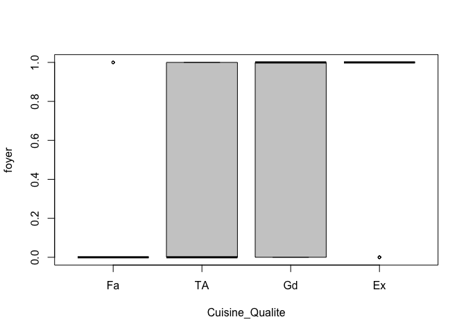

```r
A = with(data = DF, aggregate(foyer,by=list(Cuisine_Qualite),FUN=mean))
A = A[order(A$x),]
L = as.character(A$Group.1)
DF$Cuisine_Qualite= factor(DF$Cuisine_Qualite, level=L)
with(data = DF, boxplot(foyer~Cuisine_Qualite,cex=.5,col=grey(.8)))
```

```r
reg_Cuisine_Qualite= glm(foyer~Cuisine_Qualite,data = DF,family = binomial(link = "logit"))
summary(reg_Cuisine_Qualite)
```

```
##
## Call:
## glm(formula = foyer ~ Cuisine_Qualite, family = binomial(link = "logit"),
##     data = DF)
##
## Deviance Residuals:
##     Min       1Q   Median       3Q      Max
## -1.9623  -1.0061   0.5615   1.0172   1.8930
##
## Coefficients:
##                   Estimate Std. Error z value Pr(>|z|)
## (Intercept)        -1.6094     0.6325  -2.545  0.01094 *
## Cuisine_QualiteTA   1.1921     0.6418   1.857  0.06327 .
## Cuisine_QualiteGd   1.9986     0.6431   3.108  0.00188 **
## Cuisine_QualiteEx   3.3771     0.7532   4.484 7.33e-06 ***
## ---
## Signif. codes:  0 '***' 0.001 '**' 0.01 '*' 0.05 '.' 0.1 ' ' 1
##
## (Dispersion parameter for binomial family taken to be 1)
##
##     Null deviance: 1002.18  on 722  degrees of freedom
## Residual deviance:  940.57  on 719  degrees of freedom
## AIC: 948.57
##
## Number of Fisher Scoring iterations: 4
```

```r
library(car)
linearHypothesis(reg_Cuisine_Qualite, c("Cuisine_QualiteTA = 0"))
```

```
## Linear hypothesis test
##
## Hypothesis:
## Cuisine_QualiteTA = 0
##
## Model 1: restricted model
## Model 2: foyer ~ Cuisine_Qualite
##
##   Res.Df Df  Chisq Pr(>Chisq)
## 1    720
## 2    719  1 3.4496    0.06327 .
## ---
## Signif. codes:  0 '***' 0.001 '**' 0.01 '*' 0.05 '.' 0.1 ' ' 1
```

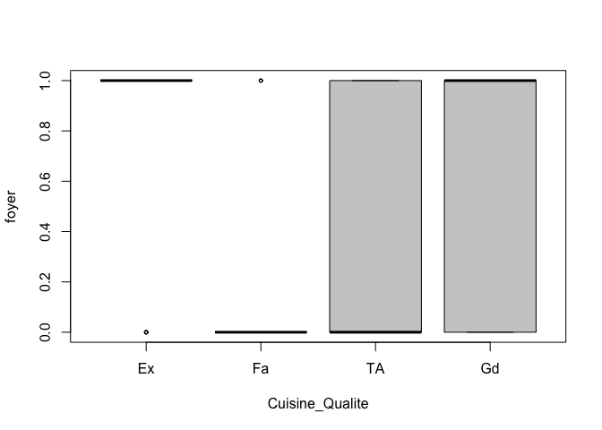

```r
DF$Cuisine_Qualite = relevel(DF$Cuisine_Qualite,"Ex")
with(data = DF, boxplot(foyer~Cuisine_Qualite,cex=.5,col=grey(.8)))
```

```r
reg_Cuisine_Qualite= glm(foyer~Cuisine_Qualite,data = DF,family = binomial(link = "logit"))
summary(reg_Cuisine_Qualite)
```

```
##
## Call:
## glm(formula = foyer ~ Cuisine_Qualite, family = binomial(link = "logit"),
##     data = DF)
##
## Deviance Residuals:
##     Min       1Q   Median       3Q      Max
## -1.9623  -1.0061   0.5615   1.0172   1.8930
##
## Coefficients:
##                   Estimate Std. Error z value Pr(>|z|)
## (Intercept)         1.7677     0.4090   4.322 1.54e-05 ***
## Cuisine_QualiteFa  -3.3771     0.7532  -4.484 7.33e-06 ***
## Cuisine_QualiteTA  -2.1850     0.4233  -5.162 2.44e-07 ***
## Cuisine_QualiteGd  -1.3785     0.4252  -3.242  0.00119 **
## ---
## Signif. codes:  0 '***' 0.001 '**' 0.01 '*' 0.05 '.' 0.1 ' ' 1
##
## (Dispersion parameter for binomial family taken to be 1)
##
##     Null deviance: 1002.18  on 722  degrees of freedom
## Residual deviance:  940.57  on 719  degrees of freedom
## AIC: 948.57
##
## Number of Fisher Scoring iterations: 4
```

Nous n’avons pas procédé au regroupement des modalités de la variable Cuisine_Qualite, car le statistique de Wald est légèrement élevé avec une p-value de 0.06327. Nous n’allons donc pas regrouper ces modalités. En revanche, nous allons tout simplement changer la modalité de référence à Cuisine_QualiteEx. Suite à cette petite modification, nous constatons que la variable Cuisine_Qualite s’avère très significative dans la régression logistique. Par conséquent, cette variable est très intéressante en raison de faible p-value et nous allons donc la retenir pour la construction du modèle.

### (1.1.19) Note

Cette fois-ci, nous allons procéder au regroupement de la variable Note similairement à la méthode utilisée pour combiner les modalités de la variable Zone, c’est-à-dire à l’aide des boîtes à moustaches et du test de Wald.

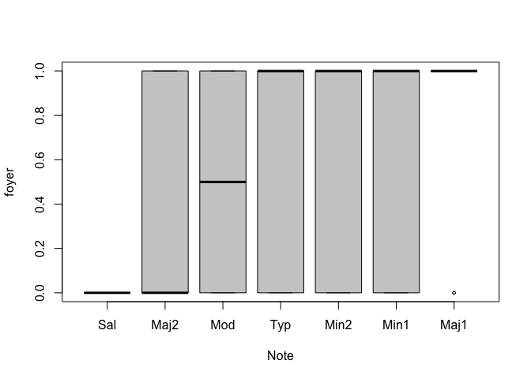

```r
A = with(data = DF, aggregate(foyer,by=list(Note),FUN=mean))
A = A[order(A$x),]
L = as.character(A$Group.1)
DF$Note= factor(DF$Note, level=L)
with(data = DF, boxplot(foyer~Note,cex=.5,col=grey(.8)))
```

```r
reg_Note = glm(foyer~Note ,data = DF,family = binomial(link = "logit"))
summary(reg_Note )
```

```
##
## Call:
## glm(formula = foyer ~ Note, family = binomial(link = "logit"),
##     data = DF)
##
## Deviance Residuals:
##     Min       1Q   Median       3Q      Max
## -2.0393  -1.1812   0.5168   1.1736   1.4823
##
## Coefficients:
##             Estimate Std. Error z value Pr(>|z|)
## (Intercept)   -13.57     535.41  -0.025    0.980
## NoteMaj2       12.87     535.41   0.024    0.981
## NoteMod        13.57     535.41   0.025    0.980
## NoteTyp        13.58     535.41   0.025    0.980
## NoteMin2       13.72     535.41   0.026    0.980
## NoteMin1       13.79     535.41   0.026    0.979
## NoteMaj1       15.51     535.41   0.029    0.977
##
## (Dispersion parameter for binomial family taken to be 1)
##
##     Null deviance: 1002.18  on 722  degrees of freedom
## Residual deviance:  994.85  on 716  degrees of freedom
## AIC: 1008.8
##
## Number of Fisher Scoring iterations: 12
```

```r
library(car)
linearHypothesis(reg_Note, c("NoteMaj2 = 0"))
```

```
## Linear hypothesis test
##
## Hypothesis:
## NoteMaj2 = 0
##
## Model 1: restricted model
## Model 2: foyer ~ Note
##
##   Res.Df Df Chisq Pr(>Chisq)
## 1    717
## 2    716  1 6e-04     0.9808
```

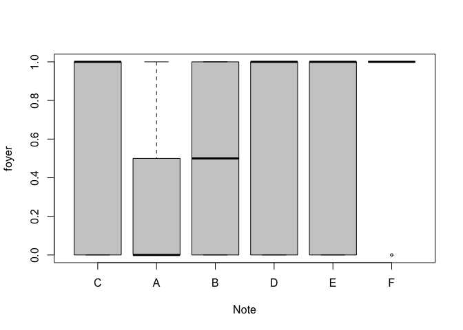

```r
levels(DF$Note) = c(rep("A",2),"B","C","D","E","F")
DF$Note = relevel(DF$Note,"C")
with(data = DF, boxplot(foyer~Note,cex=.5,col=grey(.8)))
```

```r
reg_Note = glm(foyer~Note ,data = DF,family = binomial(link = "logit"))
summary(reg_Note )
```

```
##
## Call:
## glm(formula = foyer ~ Note, family = binomial(link = "logit"),
##     data = DF)
##
## Deviance Residuals:
##     Min       1Q   Median       3Q      Max
## -2.0393  -1.1812   0.5168   1.1736   1.5829
##
## Coefficients:
##              Estimate Std. Error z value Pr(>|z|)
## (Intercept)  0.008942   0.077210   0.116   0.9078
## NoteA       -0.925233   0.840215  -1.101   0.2708
## NoteB       -0.008942   0.820139  -0.011   0.9913
## NoteD        0.145209   0.561681   0.259   0.7960
## NoteE        0.214202   0.480584   0.446   0.6558
## NoteF        1.936968   1.071825   1.807   0.0707 .
## ---
## Signif. codes:  0 '***' 0.001 '**' 0.01 '*' 0.05 '.' 0.1 ' ' 1
##
## (Dispersion parameter for binomial family taken to be 1)
##
##     Null deviance: 1002.18  on 722  degrees of freedom
## Residual deviance:  995.59  on 717  degrees of freedom
## AIC: 1007.6
##
## Number of Fisher Scoring iterations: 4
```

```r
library(car)
linearHypothesis(reg_Note, c("NoteD  = 0",
                             "NoteE = 0"))
```

```
## Linear hypothesis test
##
## Hypothesis:
## NoteD = 0
## NoteE = 0
##
## Model 1: restricted model
## Model 2: foyer ~ Note
##
##   Res.Df Df  Chisq Pr(>Chisq)
## 1    719
## 2    717  2 0.2605     0.8779
```

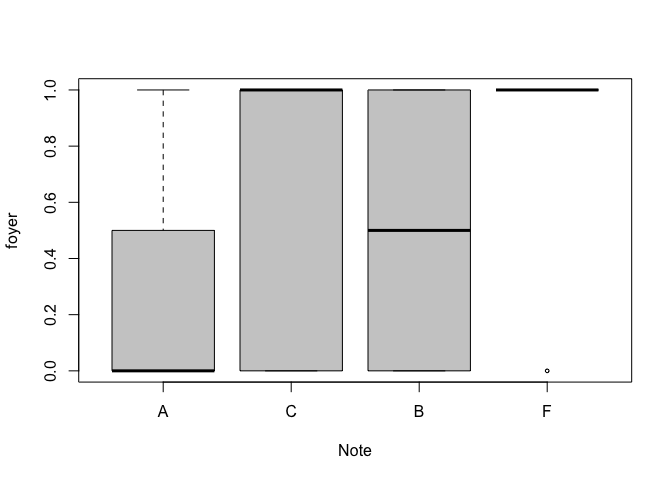

```r
levels(DF$Note) = c("C","A","B",rep("C",2),"F")
DF$Note = relevel(DF$Note,"A")
with(data = DF, boxplot(foyer~Note,cex=.5,col=grey(.8)))
```

```r
reg_Note = glm(foyer~Note ,data = DF,family = binomial(link = "logit"))
summary(reg_Note )
```

```
##
## Call:
## glm(formula = foyer ~ Note, family = binomial(link = "logit"),
##     data = DF)
##
## Deviance Residuals:
##     Min       1Q   Median       3Q      Max
## -2.0393  -1.1847   0.5168   1.1702   1.5829
##
## Coefficients:
##             Estimate Std. Error z value Pr(>|z|)
## (Intercept)  -0.9163     0.8367  -1.095    0.273
## NoteC         0.9334     0.8401   1.111    0.267
## NoteB         0.9163     1.1690   0.784    0.433
## NoteF         2.8622     1.3575   2.108    0.035 *
## ---
## Signif. codes:  0 '***' 0.001 '**' 0.01 '*' 0.05 '.' 0.1 ' ' 1
##
## (Dispersion parameter for binomial family taken to be 1)
##
##     Null deviance: 1002.18  on 722  degrees of freedom
## Residual deviance:  995.85  on 719  degrees of freedom
## AIC: 1003.8
##
## Number of Fisher Scoring iterations: 4
```

```r
library(car)
linearHypothesis(reg_Note, c("NoteB  = 0",
                             "NoteC = 0"))
```

```
## Linear hypothesis test
##
## Hypothesis:
## NoteB = 0
## NoteC = 0
##
## Model 1: restricted model
## Model 2: foyer ~ Note
##
##   Res.Df Df  Chisq Pr(>Chisq)
## 1    721
## 2    719  2 1.2347     0.5394
```

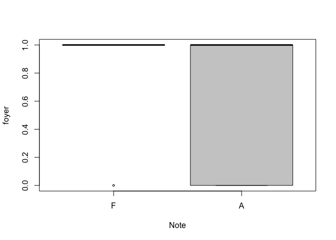

```r
levels(DF$Note) = c(rep("A",3),"F")
DF$Note = relevel(DF$Note,"F")
with(data = DF, boxplot(foyer~Note,cex=.5,col=grey(.8)))
```

```r
reg_Note = glm(foyer~Note ,data = DF,family = binomial(link = "logit"))
summary(reg_Note )
```

```
##
## Call:
## glm(formula = foyer ~ Note, family = binomial(link = "logit"),
##     data = DF)
##
## Deviance Residuals:
##     Min       1Q   Median       3Q      Max
## -2.0393  -1.1810   0.5168   1.1739   1.1739
##
## Coefficients:
##             Estimate Std. Error z value Pr(>|z|)
## (Intercept)    1.946      1.069   1.820   0.0687 .
## NoteA         -1.938      1.072  -1.808   0.0706 .
## ---
## Signif. codes:  0 '***' 0.001 '**' 0.01 '*' 0.05 '.' 0.1 ' ' 1
##
## (Dispersion parameter for binomial family taken to be 1)
##
##     Null deviance: 1002.18  on 722  degrees of freedom
## Residual deviance:  997.22  on 721  degrees of freedom
## AIC: 1001.2
##
## Number of Fisher Scoring iterations: 4
```

Où

NoteA = {Sal, Maj2, Mod, Typ, Min2, Min1}

NoteF = {Maj1}

### (1.1.20) Allee

Par la suite, nous allons procéder au regroupement de la variable Allee similairement à la méthode utilisée pour combiner les modalités de la variable Zone, c’est-à-dire à l’aide des boîtes à moustaches et du test de Wald.

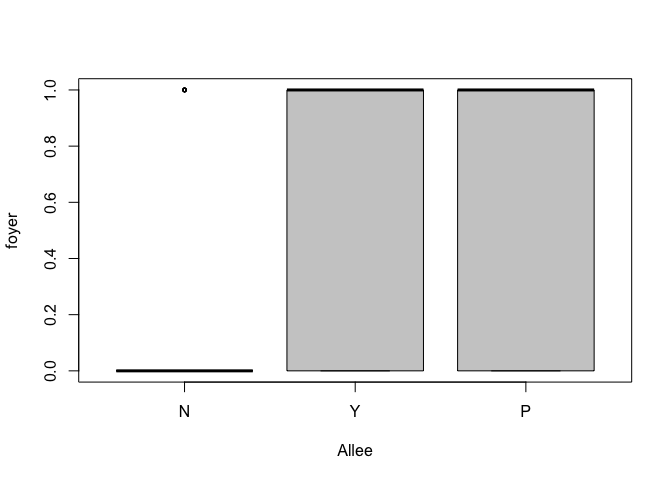

```r
A = with(data = DF, aggregate(foyer,by=list(Allee),FUN=mean))
A = A[order(A$x),]
L = as.character(A$Group.1)
DF$Allee= factor(DF$Allee, level=L)
with(data = DF, boxplot(foyer~Allee,cex=.5,col=grey(.8)))
```

```r
reg_Allee= glm(foyer~Allee,data = DF,family = binomial(link = "logit"))
summary(reg_Allee)
```

```
##
## Call:
## glm(formula = foyer ~ Allee, family = binomial(link = "logit"),
##     data = DF)
##
## Deviance Residuals:
##     Min       1Q   Median       3Q      Max
## -1.4823  -1.2336   0.9005   1.1223   1.8657
##
## Coefficients:
##             Estimate Std. Error z value Pr(>|z|)
## (Intercept)  -1.5476     0.3482  -4.444 8.84e-06 ***
## AlleeY        1.6786     0.3569   4.703 2.56e-06 ***
## AlleeP        2.2407     0.7882   2.843  0.00447 **
## ---
## Signif. codes:  0 '***' 0.001 '**' 0.01 '*' 0.05 '.' 0.1 ' ' 1
##
## (Dispersion parameter for binomial family taken to be 1)
##
##     Null deviance: 1002.18  on 722  degrees of freedom
## Residual deviance:  972.38  on 720  degrees of freedom
## AIC: 978.38
##
## Number of Fisher Scoring iterations: 4
```

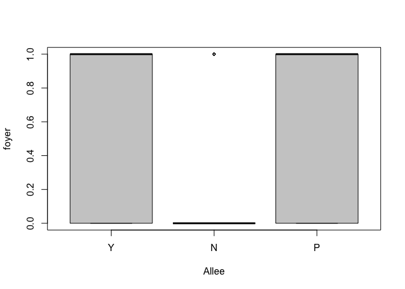

```r
DF$Allee = relevel(DF$Allee,"Y")
with(data = DF, boxplot(foyer~Allee,cex=.5,col=grey(.8)))
```

```r
reg_Allee = glm(foyer~Allee ,data = DF,family = binomial(link = "logit"))
summary(reg_Allee )
```

```
##
## Call:
## glm(formula = foyer ~ Allee, family = binomial(link = "logit"),
##     data = DF)
##
## Deviance Residuals:
##     Min       1Q   Median       3Q      Max
## -1.4823  -1.2336   0.9005   1.1223   1.8657
##
## Coefficients:
##             Estimate Std. Error z value Pr(>|z|)
## (Intercept)   0.1311     0.0782   1.676   0.0937 .
## AlleeN       -1.6786     0.3569  -4.703 2.56e-06 ***
## AlleeP        0.5621     0.7114   0.790   0.4295
## ---
## Signif. codes:  0 '***' 0.001 '**' 0.01 '*' 0.05 '.' 0.1 ' ' 1
##
## (Dispersion parameter for binomial family taken to be 1)
##
##     Null deviance: 1002.18  on 722  degrees of freedom
## Residual deviance:  972.38  on 720  degrees of freedom
## AIC: 978.38
##
## Number of Fisher Scoring iterations: 4
```

```r
library(car)
linearHypothesis(reg_Allee, c("AlleeP  = 0"))
```

```
## Linear hypothesis test
##
## Hypothesis:
## AlleeP = 0
##
## Model 1: restricted model
## Model 2: foyer ~ Allee
##
##   Res.Df Df  Chisq Pr(>Chisq)
## 1    721
## 2    720  1 0.6242     0.4295
```

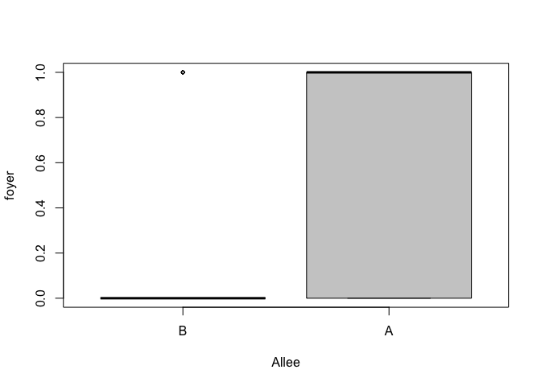

```r
levels(DF$Allee) = c("A","B","A")
DF$Allee = relevel(DF$Allee,"B")
with(data = DF, boxplot(foyer~Allee,cex=.5,col=grey(.8)))
```

```r
reg_Allee = glm(foyer~Allee ,data = DF,family = binomial(link = "logit"))
summary(reg_Allee )
```

```
##
## Call:
## glm(formula = foyer ~ Allee, family = binomial(link = "logit"),
##     data = DF)
##
## Deviance Residuals:
##    Min      1Q  Median      3Q     Max
## -1.237  -1.237   1.119   1.119   1.866
##
## Coefficients:
##             Estimate Std. Error z value Pr(>|z|)
## (Intercept)  -1.5476     0.3482  -4.444 8.82e-06 ***
## AlleeA        1.6859     0.3568   4.725 2.30e-06 ***
## ---
## Signif. codes:  0 '***' 0.001 '**' 0.01 '*' 0.05 '.' 0.1 ' ' 1
##
## (Dispersion parameter for binomial family taken to be 1)
##
##     Null deviance: 1002.18  on 722  degrees of freedom
## Residual deviance:  973.03  on 721  degrees of freedom
## AIC: 977.03
##
## Number of Fisher Scoring iterations: 3
```

Enfin, nous avons réussi à réduire le nombre de modalités pour la variable Allee et nous nous retrouvons avec les deux sous-groupes suivants : AlleeA, AlleeB. Par ailleurs, nous constatons qu’elle s’avère significative dans la régression logistique. De ce fait, cette variable est très intéressante en raison de sa faible p-value et nous allons la retenir pour la construction du modèle.

Où

AlleeA = {Y, P}

AlleeB = {N}

### (1.1.21) Vente_Type

Encore une fois, nous allons procéder au regroupement de la variable Vente_Type similairement à la méthode utilisée pour combiner les modalités de la variable Zone, c’est-à-dire à l’aide des boîtes à moustaches et du test de Wald.

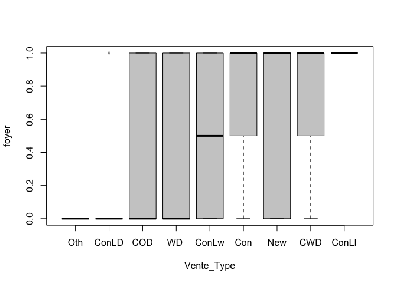

```r
A = with(data = DF, aggregate(foyer,by=list(Vente_Type),FUN=mean))
A = A[order(A$x),]
L = as.character(A$Group.1)
DF$Vente_Type= factor(DF$Vente_Type, level=L)
with(data = DF, boxplot(foyer~Vente_Type,cex=.5,col=grey(.8)))
```

```r
reg_Vente_Type= glm(foyer~Vente_Type,data = DF,family = binomial(link = "logit"))
summary(reg_Vente_Type)
```

```
##
## Call:
## glm(formula = foyer ~ Vente_Type, family = binomial(link = "logit"),
##     data = DF)
##
## Deviance Residuals:
##     Min       1Q   Median       3Q      Max
## -1.6651  -1.1665   0.7954   1.1883   1.9728
##
## Coefficients:
##                 Estimate Std. Error z value Pr(>|z|)
## (Intercept)       -13.57     535.41  -0.025    0.980
## Vente_TypeConLD    11.77     535.41   0.022    0.982
## Vente_TypeCOD      12.80     535.41   0.024    0.981
## Vente_TypeWD       13.54     535.41   0.025    0.980
## Vente_TypeConLw    13.57     535.41   0.025    0.980
## Vente_TypeCon      14.26     535.41   0.027    0.979
## Vente_TypeNew      14.55     535.41   0.027    0.978
## Vente_TypeCWD      14.66     535.41   0.027    0.978
## Vente_TypeConLI    27.13     757.19   0.036    0.971
##
## (Dispersion parameter for binomial family taken to be 1)
##
##     Null deviance: 1002.18  on 722  degrees of freedom
## Residual deviance:  978.26  on 714  degrees of freedom
## AIC: 996.26
##
## Number of Fisher Scoring iterations: 12
```

```r
library(car)
linearHypothesis(reg_Vente_Type, c("Vente_TypeConLD   = 0",
                              "Vente_TypeCOD = 0",
                              "Vente_TypeWD = 0",
                              "Vente_TypeConLw = 0"))
```

```
## Linear hypothesis test
##
## Hypothesis:
## Vente_TypeConLD = 0
## Vente_TypeCOD = 0
## Vente_TypeWD = 0
## Vente_TypeConLw = 0
##
## Model 1: restricted model
## Model 2: foyer ~ Vente_Type
##
##   Res.Df Df  Chisq Pr(>Chisq)
## 1    718
## 2    714  4 5.1082     0.2764
```

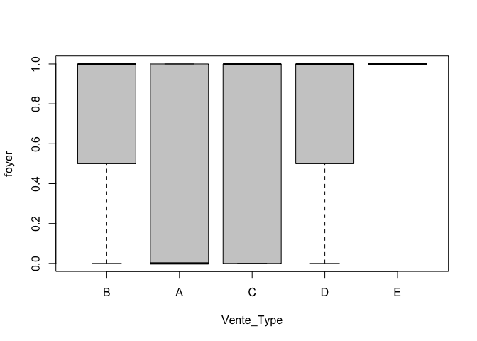

```r
levels(DF$Vente_Type) = c(rep("A",5),"B","C","D","E")
DF$Vente_Type = relevel(DF$Vente_Type,"B")
with(data = DF, boxplot(foyer~Vente_Type,cex=.5,col=grey(.8)))
```

```r
reg_Vente_Type= glm(foyer~Vente_Type,data = DF,family = binomial(link = "logit"))
summary(reg_Vente_Type)
```

```
##
## Call:
## glm(formula = foyer ~ Vente_Type, family = binomial(link = "logit"),
##     data = DF)
##
## Deviance Residuals:
##     Min       1Q   Median       3Q      Max
## -1.6651  -1.1490   0.7954   1.2060   1.2060
##
## Coefficients:
##             Estimate Std. Error z value Pr(>|z|)
## (Intercept)   0.6931     1.2247   0.566    0.571
## Vente_TypeA  -0.7602     1.2272  -0.619    0.536
## Vente_TypeC   0.2955     1.2593   0.235    0.814
## Vente_TypeD   0.4055     1.6833   0.241    0.810
## Vente_TypeE  12.8729   535.4126   0.024    0.981
##
## (Dispersion parameter for binomial family taken to be 1)
##
##     Null deviance: 1002.18  on 722  degrees of freedom
## Residual deviance:  985.95  on 718  degrees of freedom
## AIC: 995.95
##
## Number of Fisher Scoring iterations: 12
```

```r
library(car)
linearHypothesis(reg_Vente_Type, c("Vente_TypeC   = 0",
                              "Vente_TypeD = 0",
                              "Vente_TypeE = 0"))
```

```
## Linear hypothesis test
##
## Hypothesis:
## Vente_TypeC = 0
## Vente_TypeD = 0
## Vente_TypeE = 0
##
## Model 1: restricted model
## Model 2: foyer ~ Vente_Type
##
##   Res.Df Df  Chisq Pr(>Chisq)
## 1    721
## 2    718  3 0.0668     0.9955
```

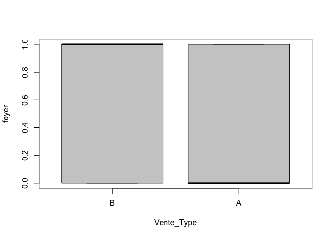

```r
levels(DF$Vente_Type) = c("B","A",rep("B",3))
DF$Vente_Type = relevel(DF$Vente_Type,"B")
with(data = DF, boxplot(foyer~Vente_Type,cex=.5,col=grey(.8)))
```

```r
reg_Vente_Type= glm(foyer~Vente_Type,data = DF,family = binomial(link = "logit"))
summary(reg_Vente_Type)
```

```
##
## Call:
## glm(formula = foyer ~ Vente_Type, family = binomial(link = "logit"),
##     data = DF)
##
## Deviance Residuals:
##    Min      1Q  Median      3Q     Max
## -1.621  -1.149   0.791   1.206   1.206
##
## Coefficients:
##             Estimate Std. Error z value Pr(>|z|)
## (Intercept)   1.0014     0.2756   3.634 0.000280 ***
## Vente_TypeA  -1.0685     0.2865  -3.730 0.000191 ***
## ---
## Signif. codes:  0 '***' 0.001 '**' 0.01 '*' 0.05 '.' 0.1 ' ' 1
##
## (Dispersion parameter for binomial family taken to be 1)
##
##     Null deviance: 1002.18  on 722  degrees of freedom
## Residual deviance:  986.65  on 721  degrees of freedom
## AIC: 990.65
##
## Number of Fisher Scoring iterations: 4
```

Enfin, nous avons réussi à réduire le nombre de modalités pour la variable Vente_Type et nous nous retrouvons avec les deux sous-groupes suivants : Vente_TypeA, Vente_TypeB. Par ailleurs, nous constatons qu’elle s’avère significative dans la régression logistique. De ce fait, cette variable est très intéressante en raison de sa faible p-value et nous allons la retenir pour la construction du modèle.

Où

Vente_TypeA = {Oth, ConLD, COD, WD, ConLw}

Vente_TypeB = {Con, New, CWD, ConLI}

### (1.1.22) Vente_Condition

Par la suite, nous allons procéder au regroupement de la variable Vente_Condition similairement à la méthode utilisée pour combiner les modalités de la variable Zone, c’est-à-dire à l’aide des boîtes à moustaches et du test de Wald.

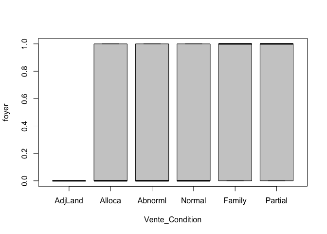

```r
A = with(data = DF, aggregate(foyer,by=list(Vente_Condition),FUN=mean))
A = A[order(A$x),]
L = as.character(A$Group.1)
DF$Vente_Condition= factor(DF$Vente_Condition, level=L)
with(data = DF, boxplot(foyer~Vente_Condition,cex=.5,col=grey(.8)))
```

```r
reg_Vente_Condition= glm(foyer~Vente_Condition,data = DF,family = binomial(link = "logit"))
summary(reg_Vente_Condition)
```

```
##
## Call:
## glm(formula = foyer ~ Vente_Condition, family = binomial(link = "logit"),
##     data = DF)
##
## Deviance Residuals:
##     Min       1Q   Median       3Q      Max
## -1.6259  -1.1659   0.7876   1.1889   1.4823
##
## Coefficients:
##                        Estimate Std. Error z value Pr(>|z|)
## (Intercept)              -14.57     509.65  -0.029    0.977
## Vente_ConditionAlloca     13.87     509.65   0.027    0.978
## Vente_ConditionAbnorml    14.30     509.65   0.028    0.978
## Vente_ConditionNormal     14.54     509.65   0.029    0.977
## Vente_ConditionFamily     14.75     509.65   0.029    0.977
## Vente_ConditionPartial    15.58     509.65   0.031    0.976
##
## (Dispersion parameter for binomial family taken to be 1)
##
##     Null deviance: 1002.18  on 722  degrees of freedom
## Residual deviance:  982.74  on 717  degrees of freedom
## AIC: 994.74
##
## Number of Fisher Scoring iterations: 13
```

```r
library(car)
linearHypothesis(reg_Vente_Condition, c("Vente_ConditionAlloca = 0",
                              "Vente_ConditionAbnorml = 0",
                              "Vente_ConditionNormal = 0"))
```

```
## Linear hypothesis test
##
## Hypothesis:
## Vente_ConditionAlloca = 0
## Vente_ConditionAbnorml = 0
## Vente_ConditionNormal = 0
##
## Model 1: restricted model
## Model 2: foyer ~ Vente_Condition
##
##   Res.Df Df  Chisq Pr(>Chisq)
## 1    720
## 2    717  3 1.2347     0.7447
```

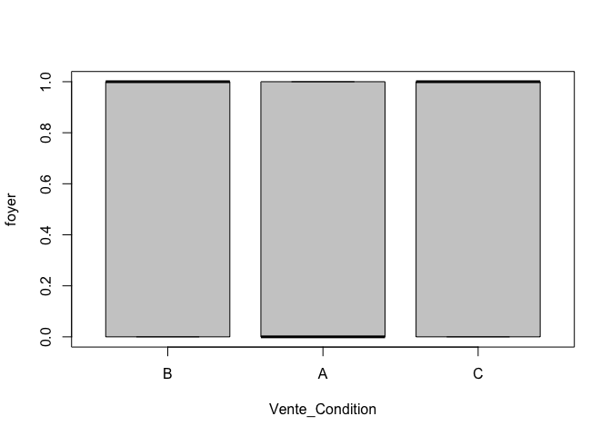

```r
levels(DF$Vente_Condition) = c(rep("A",4),"B","C")
DF$Vente_Condition = relevel(DF$Vente_Condition,"B")
with(data = DF, boxplot(foyer~Vente_Condition,cex=.5,col=grey(.8)))
```

```r
reg_Vente_Condition= glm(foyer~Vente_Condition,data = DF,family = binomial(link = "logit"))
summary(reg_Vente_Condition)
```

```
##
## Call:
## glm(formula = foyer ~ Vente_Condition, family = binomial(link = "logit"),
##     data = DF)
##
## Deviance Residuals:
##     Min       1Q   Median       3Q      Max
## -1.6259  -1.1515   0.7876   1.2036   1.2036
##
## Coefficients:
##                  Estimate Std. Error z value Pr(>|z|)
## (Intercept)        0.1823     0.6055   0.301    0.763
## Vente_ConditionA  -0.2437     0.6106  -0.399    0.690
## Vente_ConditionC   0.8293     0.6722   1.234    0.217
##
## (Dispersion parameter for binomial family taken to be 1)
##
##     Null deviance: 1002.2  on 722  degrees of freedom
## Residual deviance:  988.0  on 720  degrees of freedom
## AIC: 994
##
## Number of Fisher Scoring iterations: 4
```

```r
library(car)
linearHypothesis(reg_Vente_Condition, c("Vente_ConditionC = 0"))
```

```
## Linear hypothesis test
##
## Hypothesis:
## Vente_ConditionC = 0
##
## Model 1: restricted model
## Model 2: foyer ~ Vente_Condition
##
##   Res.Df Df  Chisq Pr(>Chisq)
## 1    721
## 2    720  1 1.5218     0.2173
```

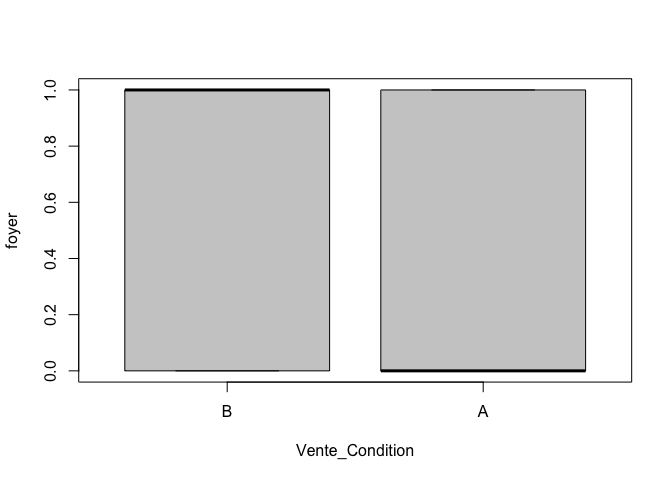

```r
levels(DF$Vente_Condition) = c("B","A","B")
DF$Vente_Condition = relevel(DF$Vente_Condition,"B")
with(data = DF, boxplot(foyer~Vente_Condition,cex=.5,col=grey(.8)))
```

```r
reg_Vente_Condition= glm(foyer~Vente_Condition,data = DF,family = binomial(link = "logit"))
summary(reg_Vente_Condition)
```

```
##
## Call:
## glm(formula = foyer ~ Vente_Condition, family = binomial(link = "logit"),
##     data = DF)
##
## Deviance Residuals:
##     Min       1Q   Median       3Q      Max
## -1.5609  -1.1515   0.8374   1.2036   1.2036
##
## Coefficients:
##                  Estimate Std. Error z value Pr(>|z|)
## (Intercept)        0.8675     0.2600   3.336 0.000850 ***
## Vente_ConditionA  -0.9289     0.2716  -3.420 0.000626 ***
## ---
## Signif. codes:  0 '***' 0.001 '**' 0.01 '*' 0.05 '.' 0.1 ' ' 1
##
## (Dispersion parameter for binomial family taken to be 1)
##
##     Null deviance: 1002.18  on 722  degrees of freedom
## Residual deviance:  989.48  on 721  degrees of freedom
## AIC: 993.48
##
## Number of Fisher Scoring iterations: 4
```

Enfin, nous avons réussi à réduire le nombre de modalités pour la variable Vente_Condition et nous nous retrouvons avec les deux sous-groupes suivants : Vente_ConditionA, Vente_ConditionB. Par ailleurs, nous constatons qu’elle s’avère significative dans la régression logistique. De ce fait, cette variable est très intéressante en raison de sa faible p-value et nous allons la retenir pour la construction du modèle.

Où

Vente_ConditionA = {AdjLand, Alloca, Abnorml, Normal}

Vente_ConditionB = {Family, Partial}

### (1.1.23) Surface_Lot

À partir de la variable Surface_Lot, les variables suivantes sont également de nature quantitative. De ce fait, il n’est pas nécessaire de faire un regroupement comme c’était le cas pour les variables catégorielles précédentes.

Remarque Surface_Lot: Nous avons ajouté un polynôme de degré 2 à la variable Surface_Lot afin d’améliorer la qualité de notre regression. Ainsi, nous constatons que la variable Surface_Lot s’avère significative dans la régression logistique. De ce fait, cette variable est très intéressante en raison de sa faible p-value et nous allons la retenir pour la construction du modèle.

```r
reg_Surface_Lot = glm(foyer~poly(Surface_Lot,2),data = DF,family = binomial(link = "logit"))
summary(reg_Surface_Lot)
```

```
##
## Call:
## glm(formula = foyer ~ poly(Surface_Lot, 2), family = binomial(link = "logit"),
##     data = DF)
##
## Deviance Residuals:
##     Min       1Q   Median       3Q      Max
## -2.9517  -1.0989   0.3848   1.0879   1.8030
##
## Coefficients:
##                        Estimate Std. Error z value Pr(>|z|)
## (Intercept)             0.05358    0.07898   0.678    0.498
## poly(Surface_Lot, 2)1  17.74774    3.25559   5.451 5.00e-08 ***
## poly(Surface_Lot, 2)2 -11.99554    2.97447  -4.033 5.51e-05 ***
## ---
## Signif. codes:  0 '***' 0.001 '**' 0.01 '*' 0.05 '.' 0.1 ' ' 1
##
## (Dispersion parameter for binomial family taken to be 1)
##
##     Null deviance: 1002.18  on 722  degrees of freedom
## Residual deviance:  923.45  on 720  degrees of freedom
## AIC: 929.45
##
## Number of Fisher Scoring iterations: 5
```

### (1.1.24) Int_Qualite

Remarque Int_Qualite: Nous constatons que la variable Int_Qualite s’avère significative dans la régression logistique. De ce fait, cette variable est très intéressante en raison de sa faible p-value et nous allons la retenir pour la construction du modèle.

```r
reg_Int_Qualite  = glm(foyer~Int_Qualite,data = DF,family = binomial(link = "logit"))
summary(reg_Int_Qualite )
```

```
##
## Call:
## glm(formula = foyer ~ Int_Qualite, family = binomial(link = "logit"),
##     data = DF)
##
## Deviance Residuals:
##     Min       1Q   Median       3Q      Max
## -2.2923  -0.8399   0.2556   0.8451   2.6277
##
## Coefficients:
##             Estimate Std. Error z value Pr(>|z|)
## (Intercept) -5.12660    0.46448  -11.04   <2e-16 ***
## Int_Qualite  0.85320    0.07616   11.20   <2e-16 ***
## ---
## Signif. codes:  0 '***' 0.001 '**' 0.01 '*' 0.05 '.' 0.1 ' ' 1
##
## (Dispersion parameter for binomial family taken to be 1)
##
##     Null deviance: 1002.18  on 722  degrees of freedom
## Residual deviance:  827.44  on 721  degrees of freedom
## AIC: 831.44
##
## Number of Fisher Scoring iterations: 4
```

### (1.1.25) Int_Condition

Remarque Int_Condition: Nous avons ajouté des nœuds à la variable Int_Condition afin d’améliorer la qualité de notre regression. Ainsi, nous constatons que la variable Int_Condition s’avère significative dans la régression logistique. De ce fait, cette variable est très intéressante en raison de sa faible p-value et nous allons la retenir pour la construction du modèle.

```r
library(splines)
reg_Int_Condition= glm(foyer~bs(Int_Condition,3),data = DF,family = binomial(link = "logit"))
summary(reg_Int_Condition)
```

```
##
## Call:
## glm(formula = foyer ~ bs(Int_Condition, 3), family = binomial(link = "logit"),
##     data = DF)
##
## Deviance Residuals:
##    Min      1Q  Median      3Q     Max
## -1.308  -1.207   1.052   1.052   1.826
##
## Coefficients:
##                       Estimate Std. Error z value Pr(>|z|)
## (Intercept)             -8.662      2.699  -3.210  0.00133 **
## bs(Int_Condition, 3)1   14.554      4.494   3.238  0.00120 **
## bs(Int_Condition, 3)2    6.674      2.060   3.239  0.00120 **
## bs(Int_Condition, 3)3    8.030      2.945   2.727  0.00639 **
## ---
## Signif. codes:  0 '***' 0.001 '**' 0.01 '*' 0.05 '.' 0.1 ' ' 1
##
## (Dispersion parameter for binomial family taken to be 1)
##
##     Null deviance: 1002.18  on 722  degrees of freedom
## Residual deviance:  969.89  on 719  degrees of freedom
## AIC: 977.89
##
## Number of Fisher Scoring iterations: 5
```

### (1.1.26) Construction_Annee

Remarque Construction_Annee: Nous constatons que la variable Construction_Annee s’avère significative dans la régression logistique. De ce fait, cette variable est très intéressante en raison de sa faible p-value et nous allons la retenir pour la construction du modèle.

```r
reg_Construction_Annee= glm(foyer~Construction_Annee,data = DF,family = binomial(link = "logit"))
summary(reg_Construction_Annee)
```

```
##
## Call:
## glm(formula = foyer ~ Construction_Annee, family = binomial(link = "logit"),
##     data = DF)
##
## Deviance Residuals:
##     Min       1Q   Median       3Q      Max
## -1.5086  -1.1199   0.8791   1.0500   1.9583
##
## Coefficients:
##                      Estimate Std. Error z value Pr(>|z|)
## (Intercept)        -38.038396   5.360501  -7.096 1.28e-12 ***
## Construction_Annee   0.019308   0.002718   7.104 1.21e-12 ***
## ---
## Signif. codes:  0 '***' 0.001 '**' 0.01 '*' 0.05 '.' 0.1 ' ' 1
##
## (Dispersion parameter for binomial family taken to be 1)
##
##     Null deviance: 1002.2  on 722  degrees of freedom
## Residual deviance:  946.6  on 721  degrees of freedom
## AIC: 950.6
##
## Number of Fisher Scoring iterations: 4
```

### (1.1.27) Renovation_Annee

Remarque Renovation_Annee: Nous constatons que la variable Renovation_Annee s’avère significative dans la régression logistique. De ce fait, cette variable est très intéressante en raison de sa faible p-value et nous allons la retenir pour la construction du modèle.

```r
reg_Renovation_Annee = glm(foyer~Renovation_Annee,data = DF,family = binomial(link = "logit"))
summary(reg_Renovation_Annee )
```

```
##
## Call:
## glm(formula = foyer ~ Renovation_Annee, family = binomial(link = "logit"),
##     data = DF)
##
## Deviance Residuals:
##     Min       1Q   Median       3Q      Max
## -1.4293  -1.1157   0.9532   1.0568   1.5024
##
## Coefficients:
##                    Estimate Std. Error z value Pr(>|z|)
## (Intercept)      -43.407082   7.452841  -5.824 5.74e-09 ***
## Renovation_Annee   0.021882   0.003754   5.829 5.59e-09 ***
## ---
## Signif. codes:  0 '***' 0.001 '**' 0.01 '*' 0.05 '.' 0.1 ' ' 1
##
## (Dispersion parameter for binomial family taken to be 1)
##
##     Null deviance: 1002.18  on 722  degrees of freedom
## Residual deviance:  966.75  on 721  degrees of freedom
## AIC: 970.75
##
## Number of Fisher Scoring iterations: 4
```

### (1.1.28) Surface_RdC

Remarque Surface_RdC: Nous constatons que la variable Surface_Rdc s’avère significative dans la régression logistique. De ce fait, cette variable est très intéressante en raison de sa faible p-value et nous allons la retenir pour la construction du modèle.

```r
reg_Surface_RdC  = glm(foyer~Surface_RdC ,data = DF,family = binomial(link = "logit"))
summary(reg_Surface_RdC )
```

```
##
## Call:
## glm(formula = foyer ~ Surface_RdC, family = binomial(link = "logit"),
##     data = DF)
##
## Deviance Residuals:
##     Min       1Q   Median       3Q      Max
## -2.1538  -0.9858   0.2067   1.0258   1.7667
##
## Coefficients:
##               Estimate Std. Error z value Pr(>|z|)
## (Intercept) -2.9006338  0.3055550  -9.493   <2e-16 ***
## Surface_RdC  0.0025582  0.0002633   9.717   <2e-16 ***
## ---
## Signif. codes:  0 '***' 0.001 '**' 0.01 '*' 0.05 '.' 0.1 ' ' 1
##
## (Dispersion parameter for binomial family taken to be 1)
##
##     Null deviance: 1002.2  on 722  degrees of freedom
## Residual deviance:  877.9  on 721  degrees of freedom
## AIC: 881.9
##
## Number of Fisher Scoring iterations: 4
```

### (1.1.29) Surface_Etage

Remarque Surface_Etage: Nous avons ajouté un polynôme de degré 2 à la variable Surface_Etage afin d’améliorer la qualité de notre regression. Ainsi, nous constatons que la variable Surface_Etage s’avère significative dans la régression logistique. De ce fait, cette variable est très intéressante en raison de sa faible p-value et nous allons la retenir pour la construction du modèle.

```r
reg_Surface_Etage= glm(foyer~poly(Surface_Etage,2) ,data = DF,family = binomial(link = "logit"))
summary(reg_Surface_Etage)
```

```
##
## Call:
## glm(formula = foyer ~ poly(Surface_Etage, 2), family = binomial(link = "logit"),
##     data = DF)
##
## Deviance Residuals:
##      Min        1Q    Median        3Q       Max
## -2.38629  -1.12203   0.09845   1.23381   1.51819
##
## Coefficients:
##                         Estimate Std. Error z value Pr(>|z|)
## (Intercept)               0.1316     0.0839   1.568    0.117
## poly(Surface_Etage, 2)1  17.9224     3.1707   5.653 1.58e-08 ***
## poly(Surface_Etage, 2)2  22.1292     4.1562   5.324 1.01e-07 ***
## ---
## Signif. codes:  0 '***' 0.001 '**' 0.01 '*' 0.05 '.' 0.1 ' ' 1
##
## (Dispersion parameter for binomial family taken to be 1)
##
##     Null deviance: 1002.2  on 722  degrees of freedom
## Residual deviance:  935.3  on 720  degrees of freedom
## AIC: 941.3
##
## Number of Fisher Scoring iterations: 5
```

### (1.1.30) Surface_Autre

Remarque Surface_Autre: Nous avons ajouté un polynôme de degré 2 à la variable Surface_Autre afin d’améliorer la qualité de notre regression. Cependant, nous constatons que la variable Surface_Autre ne s’avère pas significative dans la régression logistique. De ce fait, cette variable n’est pas intéressante en raison de sa p-value élevé et nous n’allons donc pas la retenir pour la construction du modèle.

```r
reg_Surface_Autre= glm(foyer~poly(Surface_Autre,2) ,data = DF,family = binomial(link = "logit"))
summary(reg_Surface_Autre)
```

```
##
## Call:
## glm(formula = foyer ~ poly(Surface_Autre, 2), family = binomial(link = "logit"),
##     data = DF)
##
## Deviance Residuals:
##    Min      1Q  Median      3Q     Max
## -1.252  -1.190   1.164   1.164   1.774
##
## Coefficients:
##                         Estimate Std. Error z value Pr(>|z|)
## (Intercept)              0.02435    0.07479   0.326   0.7448
## poly(Surface_Autre, 2)1  1.17604    2.88573   0.408   0.6836
## poly(Surface_Autre, 2)2  6.22778    3.73456   1.668   0.0954 .
## ---
## Signif. codes:  0 '***' 0.001 '**' 0.01 '*' 0.05 '.' 0.1 ' ' 1
##
## (Dispersion parameter for binomial family taken to be 1)
##
##     Null deviance: 1002.18  on 722  degrees of freedom
## Residual deviance:  996.93  on 720  degrees of freedom
## AIC: 1002.9
##
## Number of Fisher Scoring iterations: 4
```

### (1.1.31) Toilettes

Remarque Toilettes: Nous constatons que la variable Toillettes s’avère significative dans la régression logistique. De ce fait, cette variable est très intéressante en raison de sa faible p-value et nous allons la retenir pour la construction du modèle.

```r
reg_Toilettes= glm(foyer~Toilettes ,data = DF,family = binomial(link = "logit"))
summary(reg_Toilettes)
```

```
##
## Call:
## glm(formula = foyer ~ Toilettes, family = binomial(link = "logit"),
##     data = DF)
##
## Deviance Residuals:
##     Min       1Q   Median       3Q      Max
## -1.9707  -0.9104   0.5565   0.9505   2.0167
##
## Coefficients:
##             Estimate Std. Error z value Pr(>|z|)
## (Intercept)  -1.8932     0.2487  -7.612 2.70e-14 ***
## Toilettes     1.2267     0.1508   8.134 4.15e-16 ***
## ---
## Signif. codes:  0 '***' 0.001 '**' 0.01 '*' 0.05 '.' 0.1 ' ' 1
##
## (Dispersion parameter for binomial family taken to be 1)
##
##     Null deviance: 1002.18  on 722  degrees of freedom
## Residual deviance:  930.24  on 721  degrees of freedom
## AIC: 934.24
##
## Number of Fisher Scoring iterations: 4
```

### (1.1.32) Chambres

Remarque Chambres: Nous avons ajouté des nœuds à la variable Chambres afin d’améliorer la qualité de notre regression. Ainsi, nous constatons que la variable Chambres s’avère significative dans la régression logistique. De ce fait, cette variable est intéressante en raison de sa p-value relativement faible et nous allons la retenir pour la construction du modèle.

```r
reg_Chambres= glm(foyer~bs(Chambres,3),data = DF,family = binomial(link = "logit"))
summary(reg_Chambres)
```

```
##
## Call:
## glm(formula = foyer ~ bs(Chambres, 3), family = binomial(link = "logit"),
##     data = DF)
##
## Deviance Residuals:
##     Min       1Q   Median       3Q      Max
## -2.2563  -1.2164   0.9598   1.1389   1.3420
##
## Coefficients:
##                  Estimate Std. Error z value Pr(>|z|)
## (Intercept)         2.464      1.258   1.959   0.0501 .
## bs(Chambres, 3)1   -7.294      2.755  -2.648   0.0081 **
## bs(Chambres, 3)2    2.626      1.059   2.478   0.0132 *
## bs(Chambres, 3)3   -4.974      2.212  -2.248   0.0246 *
## ---
## Signif. codes:  0 '***' 0.001 '**' 0.01 '*' 0.05 '.' 0.1 ' ' 1
##
## (Dispersion parameter for binomial family taken to be 1)
##
##     Null deviance: 1002.18  on 722  degrees of freedom
## Residual deviance:  983.53  on 719  degrees of freedom
## AIC: 991.53
##
## Number of Fisher Scoring iterations: 4
```

### (1.1.33) Pieces

Remarque Pieces: Nous constatons que la variable Pieces s’avère significative dans la régression logistique. De ce fait, cette variable est très intéressante en raison de sa faible p-value et nous allons la retenir pour la construction du modèle.

```r
reg_Pieces= glm(foyer~Pieces,data = DF,family = binomial(link = "logit"))
summary(reg_Pieces)
```

```
##
## Call:
## glm(formula = foyer ~ Pieces, family = binomial(link = "logit"),
##     data = DF)
##
## Deviance Residuals:
##     Min       1Q   Median       3Q      Max
## -2.3926  -1.1045   0.4356   1.0440   1.9164
##
## Coefficients:
##             Estimate Std. Error z value Pr(>|z|)
## (Intercept) -3.15145    0.37861  -8.324   <2e-16 ***
## Pieces       0.49625    0.05843   8.493   <2e-16 ***
## ---
## Signif. codes:  0 '***' 0.001 '**' 0.01 '*' 0.05 '.' 0.1 ' ' 1
##
## (Dispersion parameter for binomial family taken to be 1)
##
##     Null deviance: 1002.18  on 722  degrees of freedom
## Residual deviance:  913.16  on 721  degrees of freedom
## AIC: 917.16
##
## Number of Fisher Scoring iterations: 4
```

### (1.1.34) Garage_Ext_Surface

Remarque Garage_Ext_Surface: Nous avons ajouté des nœuds à la variable Garage_Ext_Surface afin d’améliorer la qualité de notre regression. Ainsi, nous constatons que la variable Garage_Ext_Surface s’avère significative dans la régression logistique. De ce fait, cette variable est très intéressante en raison de sa faible p-value et nous allons la retenir pour la construction du modèle.

```r
reg_Garage_Ext_Surface= glm(foyer~bs(Garage_Ext_Surface,3),data = DF,family = binomial(link = "logit"))
summary(reg_Garage_Ext_Surface)
```

```
##
## Call:
## glm(formula = foyer ~ bs(Garage_Ext_Surface, 3), family = binomial(link = "logit"),
##     data = DF)
##
## Deviance Residuals:
##     Min       1Q   Median       3Q      Max
## -2.0078  -0.9787   0.8954   1.0502   1.3901
##
## Coefficients:
##                            Estimate Std. Error z value Pr(>|z|)
## (Intercept)                 -0.4872     0.1101  -4.424 9.68e-06 ***
## bs(Garage_Ext_Surface, 3)1   4.1916     0.7421   5.648 1.62e-08 ***
## bs(Garage_Ext_Surface, 3)2  -4.8265     1.8326  -2.634  0.00845 **
## bs(Garage_Ext_Surface, 3)3   5.3818     2.5416   2.118  0.03422 *
## ---
## Signif. codes:  0 '***' 0.001 '**' 0.01 '*' 0.05 '.' 0.1 ' ' 1
##
## (Dispersion parameter for binomial family taken to be 1)
##
##     Null deviance: 1002.18  on 722  degrees of freedom
## Residual deviance:  957.26  on 719  degrees of freedom
## AIC: 965.26
##
## Number of Fisher Scoring iterations: 4
```

### (1.1.35) Garage_Int_Surface

Remarque Garage_Int_Surface: Nous constatons que la variable Garage_Int_Surface ne s’avère pas significative dans la régression logistique. En effet, cette variable n’est pas très intéressante en raison de sa p-value trop élevée et nous n’allons pas la retenir pour la construction du modèle.

```r
reg_Garage_Int_Surface= glm(foyer~Garage_Int_Surface,data = DF,family = binomial(link = "logit"))
summary(reg_Garage_Int_Surface)
```

```
##
## Call:
## glm(formula = foyer ~ Garage_Int_Surface, family = binomial(link = "logit"),
##     data = DF)
##
## Deviance Residuals:
##    Min      1Q  Median      3Q     Max
## -1.189  -1.189   1.166   1.166   1.183
##
## Coefficients:
##                      Estimate Std. Error z value Pr(>|z|)
## (Intercept)         2.648e-02  7.942e-02   0.333    0.739
## Garage_Int_Surface -6.643e-05  1.165e-03  -0.057    0.955
##
## (Dispersion parameter for binomial family taken to be 1)
##
##     Null deviance: 1002.2  on 722  degrees of freedom
## Residual deviance: 1002.2  on 721  degrees of freedom
## AIC: 1006.2
##
## Number of Fisher Scoring iterations: 3
```

### (1.1.36) Piscine_Surface

Remarque Piscine_Surface: Nous constatons que la variable Piscine_Surface ne s’avère pas significative dans la régression logistique. En effet, cette variable n’est pas très intéressante en raison de sa p-value trop élevée et nous n’allons pas la retenir pour la construction du modèle.

```r
reg_Piscine_Surface= glm(foyer~Piscine_Surface,data = DF,family = binomial(link = "logit"))
summary(reg_Piscine_Surface)
```

```
##
## Call:
## glm(formula = foyer ~ Piscine_Surface, family = binomial(link = "logit"),
##     data = DF)
##
## Deviance Residuals:
##    Min      1Q  Median      3Q     Max
## -1.185  -1.185   1.170   1.170   1.170
##
## Coefficients:
##                 Estimate Std. Error z value Pr(>|z|)
## (Intercept)      0.01667    0.07454   0.224    0.823
## Piscine_Surface  0.09053    2.87454   0.031    0.975
##
## (Dispersion parameter for binomial family taken to be 1)
##
##     Null deviance: 1002.18  on 722  degrees of freedom
## Residual deviance:  998.08  on 721  degrees of freedom
## AIC: 1002.1
##
## Number of Fisher Scoring iterations: 14
```

### (1.1.37) Vente_Mois

Remarque Vente_Mois: Nous constatons que la variable Vente_Mois ne s’avère pas significative dans la régression logistique. En effet, cette variable n’est pas très intéressante en raison de sa p-value trop élevée et nous n’allons pas la retenir pour la construction du modèle.

```r
reg_Vente_Mois= glm(foyer~Vente_Mois,data = DF,family = binomial(link = "logit"))
summary(reg_Vente_Mois)
```

```
##
## Call:
## glm(formula = foyer ~ Vente_Mois, family = binomial(link = "logit"),
##     data = DF)
##
## Deviance Residuals:
##    Min      1Q  Median      3Q     Max
## -1.260  -1.191   1.097   1.164   1.246
##
## Coefficients:
##             Estimate Std. Error z value Pr(>|z|)
## (Intercept)  0.22346    0.18635   1.199    0.230
## Vente_Mois  -0.03188    0.02742  -1.162    0.245
##
## (Dispersion parameter for binomial family taken to be 1)
##
##     Null deviance: 1002.2  on 722  degrees of freedom
## Residual deviance: 1000.8  on 721  degrees of freedom
## AIC: 1004.8
##
## Number of Fisher Scoring iterations: 3
```

### (1.1.38) Vente_Annee

Remarque Vente_Annee: Nous constatons que la variable Vente_Annee ne s’avère pas significative dans la régression logistique. En effet, cette variable n’est pas très intéressante en raison de sa p-value trop élevée et nous n’allons pas la retenir pour la construction du modèle.

```r
reg_Vente_Annee= glm(foyer~Vente_Annee,data = DF,family = binomial(link = "logit"))
summary(reg_Vente_Annee)
```

```
##
## Call:
## glm(formula = foyer ~ Vente_Annee, family = binomial(link = "logit"),
##     data = DF)
##
## Deviance Residuals:
##    Min      1Q  Median      3Q     Max
## -1.192  -1.188   1.163   1.167   1.170
##
## Coefficients:
##               Estimate Std. Error z value Pr(>|z|)
## (Intercept)  -8.993124 116.232553  -0.077    0.938
## Vente_Annee   0.004491   0.057890   0.078    0.938
##
## (Dispersion parameter for binomial family taken to be 1)
##
##     Null deviance: 1002.2  on 722  degrees of freedom
## Residual deviance: 1002.2  on 721  degrees of freedom
## AIC: 1006.2
##
## Number of Fisher Scoring iterations: 3
```

### (1.1.39) Rue

Remarque Rue : La variable Rue ne possède que deux modalités dont Grvl et Pave. Cette dernière modalié représente en effet 100% des maisons vendues dans la base de données. Par conséquent, nous ne pouvons malheureusement pas faire une régression logistique sous R. De ce fait, nous n’allons pas la retenir pour la construction du modèle.

```r
table(DF$Rue)
```

```
##
## Grvl Pave
##    0  723
```

## (1.2) LISTES DE VARIABLES EXPLICATIVES RETENUES

En somme, nous sommes parvenus à effectivement réduire le nombre de variables explicatives susceptibles à être sélectionnées pour la construction du modèle. Voici donc une liste exhaustive des 31 variables explicatives retenues :

- Zone
- Forme
- Configuration
- Proxim_1
- Logement
- Style
- Toit
- Exterieur
- Maconnerie
- Ext_Qualite
- Ext_Condition
- Foundation
- Chauffage
- Chauff_Qualite
- Electricite
- Cuisine_Qualite
- Note
- Allee
- Vente_Type
- Vente_Condition
- Surface_Lot
- Int_Qualite
- Int_Condition
- Construction_Annee
- Renovation_Annee
- Surface_RdC
- Surface_Etage
- Toilettes
- Chambres
- Pieces
- Garage_Ext_Surface

Également, voici une liste exhaustive de variables explicatives rejetées :

- Utilities
- Proxim_2
- Surface_Autre
- Garage_Int_Surface
- Piscine_Surface
- Vente_Mois
- Vente_Annee
- Rue

# PARTIE II

Dans cette deuxième partie du projet, nous expliquerons de façon détaillée comment nous sommes parvenus à l’amélioration d’un modèle simple. Parallèlement, nous expliquerons également la démarche utilisée permettant de construire un second modèle plus complexe et d’illustrer les moyens de le simplifier.

## (2.1) MODÈLE SIMPLE

À priori, nous avons décidé de créer un modèle initial avec les variables Zone, Forme, Surface_RdC et Pieces, puisqu’elles nous semblaient être les plus intéressantes à inclure en raison de leur très faible p-value lorsqu’elles sont combinées ensembles. Pour améliorer notre modèle simple, nous allons tout simplement procédé par la méthode de pas à pas (Stepwise). Plus précisément, nous avons procédé par « Forwad selection » en ajoutant ou en retirant une variable explicative à la fois et en vérifiant également, à chaque modification, leur significativité dans la régression à l’aide d’un test Z, c’est-à-dire un test de statistique dans lequel la statistique de test suit une loi gaussienne sous l’hypothèse nulle. Par ailleurs, nous allons comparé à chaque étape leur indice AIC. Certes, nous désirons idéalement obtenir, à la fin, un indice AIC inférieur aux modèles précédents.

```r
modele_00 = glm(foyer~Zone
+ Forme
#+ Configuration
#+ Proxim_1
#+ Logement
#+ Style
#+ Toit
#+ Exterieur
#+ Maconnerie
#+ Ext_Qualite
#+ Ext_Condition
#+ Foundation
#+ Chauffage
#+ Chauff_Qualite
#+ Electricite
#+ Cuisine_Qualite
#+ Note
#+ Allee
#+ Vente_Type
#+ Vente_Condition
#+ poly(Surface_Lot, 2)
#+ Int_Qualite
#+ bs(Int_Condition ,3)
#+ Construction_Annee
#+ Renovation_Annee
+ Surface_RdC
#+ poly(Surface_Etage, 2)
#+ Toilettes
#+ bs(Chambres, 3)
+ Pieces
#+ bs(Garage_Ext_Surface, 3)
,data = DF, family = binomial(link = logit))

summary(modele_00)
```

```
##
## Call:
## glm(formula = foyer ~ Zone + Forme + Surface_RdC + Pieces, family = binomial(link = logit),
##     data = DF)
##
## Deviance Residuals:
##     Min       1Q   Median       3Q      Max
## -2.5202  -0.9145   0.1711   0.9142   2.4047
##
## Coefficients:
##               Estimate Std. Error z value Pr(>|z|)
## (Intercept) -4.6652812  0.5336905  -8.742  < 2e-16 ***
## ZoneB        0.8549026  0.2317059   3.690 0.000225 ***
## FormeB      -0.8070350  0.1828842  -4.413 1.02e-05 ***
## Surface_RdC  0.0018522  0.0002845   6.511 7.49e-11 ***
## Pieces       0.3742848  0.0629477   5.946 2.75e-09 ***
## ---
## Signif. codes:  0 '***' 0.001 '**' 0.01 '*' 0.05 '.' 0.1 ' ' 1
##
## (Dispersion parameter for binomial family taken to be 1)
##
##     Null deviance: 1002.18  on 722  degrees of freedom
## Residual deviance:  795.74  on 718  degrees of freedom
## AIC: 805.74
##
## Number of Fisher Scoring iterations: 4
```

```r
AIC(modele_00)
```

```
## [1] 805.7382
```

### (2.1.1) Modele_01

Remarque modele_01 : Nous avons ajouté la variable Logement, car elle s’avère très significative dans la régression logisitique selon le test Z. De plus, l’indice AIC a effectivement diminué.

```r
modele_01 = glm(foyer~Zone
+ Forme
#+ Configuration
#+ Proxim_1
+ Logement
#+ Style
#+ Toit
#+ Exterieur
#+ Maconnerie
#+ Ext_Qualite
#+ Ext_Condition
#+ Foundation
#+ Chauffage
#+ Chauff_Qualite
#+ Electricite
#+ Cuisine_Qualite
#+ Note
#+ Allee
#+ Vente_Type
#+ Vente_Condition
#+ poly(Surface_Lot, 2)
#+ Int_Qualite
#+ bs(Int_Condition ,3)
#+ Construction_Annee
#+ Renovation_Annee
+ Surface_RdC
#+ poly(Surface_Etage, 2)
#+ Toilettes
#+ bs(Chambres, 3)
+ Pieces
#+ bs(Garage_Ext_Surface, 3)
,data = DF, family = binomial(link = logit))

summary(modele_01)
```

```
##
## Call:
## glm(formula = foyer ~ Zone + Forme + Logement + Surface_RdC +
##     Pieces, family = binomial(link = logit), data = DF)
##
## Deviance Residuals:
##     Min       1Q   Median       3Q      Max
## -2.4537  -0.8755   0.1434   0.8585   2.4216
##
## Coefficients:
##               Estimate Std. Error z value Pr(>|z|)
## (Intercept) -7.2209699  0.7705381  -9.371  < 2e-16 ***
## ZoneB        0.7962634  0.2368981   3.361 0.000776 ***
## FormeB      -0.7349468  0.1875293  -3.919 8.89e-05 ***
## LogementB    2.2279671  0.4302945   5.178 2.25e-07 ***
## Surface_RdC  0.0018760  0.0002932   6.397 1.58e-10 ***
## Pieces       0.4445570  0.0676568   6.571 5.01e-11 ***
## ---
## Signif. codes:  0 '***' 0.001 '**' 0.01 '*' 0.05 '.' 0.1 ' ' 1
##
## (Dispersion parameter for binomial family taken to be 1)
##
##     Null deviance: 1002.18  on 722  degrees of freedom
## Residual deviance:  760.74  on 717  degrees of freedom
## AIC: 772.74
##
## Number of Fisher Scoring iterations: 5
```

```r
AIC(modele_01)
```

```
## [1] 772.7429
```

### (2.1.2) Modele_02

Remarque modele_02 : Nous avons ajouté la variable Sytle, car elle s’avère très significative dans la régression logisitique selon le test Z. De plus, l’indice AIC a effectivement diminué.

```r
modele_02 = glm(foyer~Zone
+ Forme
#+ Configuration
#+ Proxim_1
+ Logement
+ Style
#+ Toit
#+ Exterieur
#+ Maconnerie
#+ Ext_Qualite
#+ Ext_Condition
#+ Foundation
#+ Chauffage
#+ Chauff_Qualite
#+ Electricite
#+ Cuisine_Qualite
#+ Note
#+ Allee
#+ Vente_Type
#+ Vente_Condition
#+ poly(Surface_Lot, 2)
#+ Int_Qualite
#+ bs(Int_Condition ,3)
#+ Construction_Annee
#+ Renovation_Annee
+ Surface_RdC
#+ poly(Surface_Etage, 2)
#+ Toilettes
#+ bs(Chambres, 3)
+ Pieces
#+ bs(Garage_Ext_Surface, 3)
,data = DF, family = binomial(link = logit))

summary(modele_02)
```

```
##
## Call:
## glm(formula = foyer ~ Zone + Forme + Logement + Style + Surface_RdC +
##     Pieces, family = binomial(link = logit), data = DF)
##
## Deviance Residuals:
##     Min       1Q   Median       3Q      Max
## -2.4958  -0.8541   0.1382   0.8249   2.6369
##
## Coefficients:
##               Estimate Std. Error z value Pr(>|z|)
## (Intercept) -5.8490291  0.7997153  -7.314 2.60e-13 ***
## ZoneB        0.8010848  0.2396867   3.342 0.000831 ***
## FormeB      -0.5766283  0.1932988  -2.983 0.002854 **
## LogementB    2.0052183  0.4132578   4.852 1.22e-06 ***
## StyleA      -1.1676156  0.2681179  -4.355 1.33e-05 ***
## Surface_RdC  0.0027256  0.0003671   7.425 1.13e-13 ***
## Pieces       0.2173340  0.0837588   2.595 0.009466 **
## ---
## Signif. codes:  0 '***' 0.001 '**' 0.01 '*' 0.05 '.' 0.1 ' ' 1
##
## (Dispersion parameter for binomial family taken to be 1)
##
##     Null deviance: 1002.18  on 722  degrees of freedom
## Residual deviance:  740.98  on 716  degrees of freedom
## AIC: 754.98
##
## Number of Fisher Scoring iterations: 5
```

```r
AIC(modele_02)
```

```
## [1] 754.9793
```

### (2.1.3) Modele_03

Remarque modele_03 : Nous avons ajouté la variable Exterieur, car elle s’avère significative dans la régression logisitique selon le test Z. De plus, l’indice AIC a effectivement diminué.

```r
modele_03 = glm(foyer~Zone
+ Forme
#+ Configuration
#+ Proxim_1
+ Logement
+ Style
#+ Toit
+ Exterieur
#+ Maconnerie
#+ Ext_Qualite
#+ Ext_Condition
#+ Foundation
#+ Chauffage
#+ Chauff_Qualite
#+ Electricite
#+ Cuisine_Qualite
#+ Note
#+ Allee
#+ Vente_Type
#+ Vente_Condition
#+ poly(Surface_Lot, 2)
#+ Int_Qualite
#+ bs(Int_Condition ,3)
#+ Construction_Annee
#+ Renovation_Annee
+ Surface_RdC
#+ poly(Surface_Etage, 2)
#+ Toilettes
#+ bs(Chambres, 3)
+ Pieces
#+ bs(Garage_Ext_Surface, 3)
,data = DF, family = binomial(link = logit))

summary(modele_03)
```

```
##
## Call:
## glm(formula = foyer ~ Zone + Forme + Logement + Style + Exterieur +
##     Surface_RdC + Pieces, family = binomial(link = logit), data = DF)
##
## Deviance Residuals:
##     Min       1Q   Median       3Q      Max
## -2.5420  -0.7903   0.1318   0.7955   2.5326
##
## Coefficients:
##               Estimate Std. Error z value Pr(>|z|)
## (Intercept) -6.0191796  0.8111658  -7.420 1.17e-13 ***
## ZoneB        0.7672436  0.2404695   3.191  0.00142 **
## FormeB      -0.6059973  0.1953403  -3.102  0.00192 **
## LogementB    1.9536741  0.4128166   4.733 2.22e-06 ***
## StyleA      -1.1294867  0.2691170  -4.197 2.70e-05 ***
## ExterieurB   0.6109611  0.1930281   3.165  0.00155 **
## Surface_RdC  0.0026628  0.0003686   7.224 5.04e-13 ***
## Pieces       0.2030064  0.0843323   2.407  0.01607 *
## ---
## Signif. codes:  0 '***' 0.001 '**' 0.01 '*' 0.05 '.' 0.1 ' ' 1
##
## (Dispersion parameter for binomial family taken to be 1)
##
##     Null deviance: 1002.18  on 722  degrees of freedom
## Residual deviance:  730.89  on 715  degrees of freedom
## AIC: 746.89
##
## Number of Fisher Scoring iterations: 5
```

```r
AIC(modele_03)
```

```
## [1] 746.8878
```

### (2.1.4) Modele_04

Remarque modele_04 : Nous avons ajouté la variable Maconnerie, car elle s’avère significative dans la régression logisitique selon le test Z. De plus, l’indice AIC a effectivement diminué.

```r
modele_04 = glm(foyer~Zone
+ Forme
#+ Configuration
#+ Proxim_1
+ Logement
+ Style
#+ Toit
+ Exterieur
+ Maconnerie
#+ Ext_Qualite
#+ Ext_Condition
#+ Foundation
#+ Chauffage
#+ Chauff_Qualite
#+ Electricite
#+ Cuisine_Qualite
#+ Note
#+ Allee
#+ Vente_Type
#+ Vente_Condition
#+ poly(Surface_Lot, 2)
#+ Int_Qualite
#+ bs(Int_Condition ,3)
#+ Construction_Annee
#+ Renovation_Annee
+ Surface_RdC
#+ poly(Surface_Etage, 2)
#+ Toilettes
#+ bs(Chambres, 3)
+ Pieces
#+ bs(Garage_Ext_Surface, 3)
,data = DF, family = binomial(link = logit))

summary(modele_04)
```

```
##
## Call:
## glm(formula = foyer ~ Zone + Forme + Logement + Style + Exterieur +
##     Maconnerie + Surface_RdC + Pieces, family = binomial(link = logit),
##     data = DF)
##
## Deviance Residuals:
##     Min       1Q   Median       3Q      Max
## -2.3846  -0.7974   0.1519   0.7954   2.5516
##
## Coefficients:
##               Estimate Std. Error z value Pr(>|z|)
## (Intercept) -5.8881553  0.8071564  -7.295 2.99e-13 ***
## ZoneB        0.7561971  0.2454373   3.081 0.002063 **
## FormeB      -0.5932947  0.1988227  -2.984 0.002845 **
## LogementB    1.9213691  0.4120594   4.663 3.12e-06 ***
## StyleA      -1.0054333  0.2713795  -3.705 0.000211 ***
## ExterieurB   0.6656729  0.1972245   3.375 0.000738 ***
## MaconnerieA  0.4988672  0.2149502   2.321 0.020295 *
## MaconnerieC  1.4572005  0.4494270   3.242 0.001185 **
## Surface_RdC  0.0021649  0.0003874   5.588 2.29e-08 ***
## Pieces       0.2199910  0.0842758   2.610 0.009044 **
## ---
## Signif. codes:  0 '***' 0.001 '**' 0.01 '*' 0.05 '.' 0.1 ' ' 1
##
## (Dispersion parameter for binomial family taken to be 1)
##
##     Null deviance: 1002.18  on 722  degrees of freedom
## Residual deviance:  716.29  on 713  degrees of freedom
## AIC: 736.29
##
## Number of Fisher Scoring iterations: 5
```

```r
AIC(modele_04)
```

```
## [1] 736.2857
```

### (2.1.5) Modele_05

Remarque modele_05 : Nous avons ajouté la variable Note, car elle s’avère significative dans la régression logisitique selon le test Z. De plus, l’indice AIC a effectivement diminué.

```r
modele_05 = glm(foyer~Zone
+ Forme
#+ Configuration
#+ Proxim_1
+ Logement
+ Style
#+ Toit
+ Exterieur
+ Maconnerie
#+ Ext_Qualite
#+ Ext_Condition
#+ Foundation
#+ Chauffage
#+ Chauff_Qualite
#+ Electricite
#+ Cuisine_Qualite
+ Note
#+ Allee
#+ Vente_Type
#+ Vente_Condition
#+ poly(Surface_Lot, 2)
#+ Int_Qualite
#+ bs(Int_Condition ,3)
#+ Construction_Annee
#+ Renovation_Annee
+ Surface_RdC
#+ poly(Surface_Etage, 2)
#+ Toilettes
#+ bs(Chambres, 3)
+ Pieces
#+ bs(Garage_Ext_Surface, 3)
,data = DF, family = binomial(link = logit))

summary(modele_05)
```

```
##
## Call:
## glm(formula = foyer ~ Zone + Forme + Logement + Style + Exterieur +
##     Maconnerie + Note + Surface_RdC + Pieces, family = binomial(link = logit),
##     data = DF)
##
## Deviance Residuals:
##     Min       1Q   Median       3Q      Max
## -2.3749  -0.7873   0.1115   0.7991   2.5486
##
## Coefficients:
##              Estimate Std. Error z value Pr(>|z|)
## (Intercept) -3.209782   1.529793  -2.098 0.035889 *
## ZoneB        0.807213   0.248582   3.247 0.001165 **
## FormeB      -0.609852   0.199586  -3.056 0.002246 **
## LogementB    1.899507   0.413666   4.592 4.39e-06 ***
## StyleA      -0.979747   0.272641  -3.594 0.000326 ***
## ExterieurB   0.700885   0.198973   3.523 0.000427 ***
## MaconnerieA  0.526768   0.216138   2.437 0.014802 *
## MaconnerieC  1.491006   0.450046   3.313 0.000923 ***
## NoteA       -2.707348   1.370172  -1.976 0.048164 *
## Surface_RdC  0.002121   0.000389   5.453 4.96e-08 ***
## Pieces       0.220287   0.085575   2.574 0.010048 *
## ---
## Signif. codes:  0 '***' 0.001 '**' 0.01 '*' 0.05 '.' 0.1 ' ' 1
##
## (Dispersion parameter for binomial family taken to be 1)
##
##     Null deviance: 1002.18  on 722  degrees of freedom
## Residual deviance:  711.83  on 712  degrees of freedom
## AIC: 733.83
##
## Number of Fisher Scoring iterations: 5
```

```r
AIC(modele_05)
```

```
## [1] 733.8309
```

### (2.1.6) Modele_06

```r
modele_06 = glm(foyer~Zone
+ Forme
#+ Configuration
#+ Proxim_1
+ Logement
+ Style
#+ Toit
+ Exterieur
+ Maconnerie
#+ Ext_Qualite
#+ Ext_Condition
#+ Foundation
#+ Chauffage
#+ Chauff_Qualite
#+ Electricite
#+ Cuisine_Qualite
+ Note
+ Allee
#+ Vente_Type
#+ Vente_Condition
#+ poly(Surface_Lot, 2)
#+ Int_Qualite
#+ bs(Int_Condition ,3)
#+ Construction_Annee
#+ Renovation_Annee
+ Surface_RdC
#+ poly(Surface_Etage, 2)
#+ Toilettes
#+ bs(Chambres, 3)
+ Pieces
#+ bs(Garage_Ext_Surface, 3)
,data = DF, family = binomial(link = logit))

summary(modele_06)
```

```
##
## Call:
## glm(formula = foyer ~ Zone + Forme + Logement + Style + Exterieur +
##     Maconnerie + Note + Allee + Surface_RdC + Pieces, family = binomial(link = logit),
##     data = DF)
##
## Deviance Residuals:
##     Min       1Q   Median       3Q      Max
## -2.3885  -0.7805   0.1001   0.7852   2.5481
##
## Coefficients:
##               Estimate Std. Error z value Pr(>|z|)
## (Intercept) -3.3124317  1.5628758  -2.119 0.034053 *
## ZoneB        0.7162895  0.2544231   2.815 0.004872 **
## FormeB      -0.5938083  0.2002491  -2.965 0.003023 **
## LogementB    1.8345977  0.4141236   4.430 9.42e-06 ***
## StyleA      -0.9085271  0.2741131  -3.314 0.000918 ***
## ExterieurB   0.7253648  0.1996775   3.633 0.000280 ***
## MaconnerieA  0.4922031  0.2171166   2.267 0.023390 *
## MaconnerieC  1.4324838  0.4492015   3.189 0.001428 **
## NoteA       -3.2670966  1.4596523  -2.238 0.025203 *
## AlleeA       0.7560004  0.4317231   1.751 0.079925 .
## Surface_RdC  0.0020367  0.0003913   5.205 1.94e-07 ***
## Pieces       0.2397340  0.0868414   2.761 0.005770 **
## ---
## Signif. codes:  0 '***' 0.001 '**' 0.01 '*' 0.05 '.' 0.1 ' ' 1
##
## (Dispersion parameter for binomial family taken to be 1)
##
##     Null deviance: 1002.18  on 722  degrees of freedom
## Residual deviance:  708.47  on 711  degrees of freedom
## AIC: 732.47
##
## Number of Fisher Scoring iterations: 5
```

```r
AIC(modele_06)
```

```
## [1] 732.4738
```

### (2.1.7) Modele_07

Remarque modele_07 : Nous avons ajouté la variable Int_Qualite, car elle s’avère très significative dans la régression logisitique selon le test Z. De plus, l’indice AIC a effectivement diminué.

```r
modele_07 = glm(foyer~Zone
+ Forme
#+ Configuration
#+ Proxim_1
+ Logement
+ Style
#+ Toit
+ Exterieur
+ Maconnerie
#+ Ext_Qualite
#+ Ext_Condition
#+ Foundation
#+ Chauffage
#+ Chauff_Qualite
#+ Electricite
#+ Cuisine_Qualite
+ Note
+ Allee
#+ Vente_Type
#+ Vente_Condition
#+ poly(Surface_Lot, 2)
+ Int_Qualite
#+ bs(Int_Condition ,3)
#+ Construction_Annee
#+ Renovation_Annee
+ Surface_RdC
#+ poly(Surface_Etage, 2)
#+ Toilettes
#+ bs(Chambres, 3)
+ Pieces
#+ bs(Garage_Ext_Surface, 3)
,data = DF, family = binomial(link = logit))

summary(modele_07)
```

```
##
## Call:
## glm(formula = foyer ~ Zone + Forme + Logement + Style + Exterieur +
##     Maconnerie + Note + Allee + Int_Qualite + Surface_RdC + Pieces,
##     family = binomial(link = logit), data = DF)
##
## Deviance Residuals:
##      Min        1Q    Median        3Q       Max
## -2.42293  -0.74870   0.08823   0.74988   2.51573
##
## Coefficients:
##              Estimate Std. Error z value Pr(>|z|)
## (Intercept) -3.655418   1.571648  -2.326 0.020027 *
## ZoneB        0.851347   0.261701   3.253 0.001141 **
## FormeB      -0.458371   0.205046  -2.235 0.025387 *
## LogementB    1.537551   0.410990   3.741 0.000183 ***
## StyleA      -0.603510   0.282600  -2.136 0.032715 *
## ExterieurB   0.563448   0.206883   2.724 0.006459 **
## MaconnerieA  0.332602   0.223544   1.488 0.136788
## MaconnerieC  1.071543   0.466427   2.297 0.021599 *
## NoteA       -4.259099   1.514944  -2.811 0.004933 **
## AlleeA       0.570439   0.434824   1.312 0.189559
## Int_Qualite  0.370901   0.102682   3.612 0.000304 ***
## Surface_RdC  0.001524   0.000412   3.700 0.000216 ***
## Pieces       0.226357   0.086552   2.615 0.008916 **
## ---
## Signif. codes:  0 '***' 0.001 '**' 0.01 '*' 0.05 '.' 0.1 ' ' 1
##
## (Dispersion parameter for binomial family taken to be 1)
##
##     Null deviance: 1002.18  on 722  degrees of freedom
## Residual deviance:  694.98  on 710  degrees of freedom
## AIC: 720.98
##
## Number of Fisher Scoring iterations: 5
```

```r
AIC(modele_07)
```

```
## [1] 720.9761
```

### (2.1.8) Modele_08

Remarque modele_08 : Nous avons ajouté la variable Construction_Annee, car elle s’avère significative dans la régression logisitique selon le test Z. De plus, l’indice AIC a effectivement diminué.

```r
modele_08 = glm(foyer~Zone
+ Forme
#+ Configuration
#+ Proxim_1
+ Logement
+ Style
#+ Toit
+ Exterieur
+ Maconnerie
#+ Ext_Qualite
#+ Ext_Condition
#+ Foundation
#+ Chauffage
#+ Chauff_Qualite
#+ Electricite
#+ Cuisine_Qualite
+ Note
+ Allee
#+ Vente_Type
#+ Vente_Condition
#+ poly(Surface_Lot, 2)
+ Int_Qualite
#+ bs(Int_Condition ,3)
+ Construction_Annee
#+ Renovation_Annee
+ Surface_RdC
#+ poly(Surface_Etage, 2)
#+ Toilettes
#+ bs(Chambres, 3)
+ Pieces
#+ bs(Garage_Ext_Surface, 3)
,data = DF, family = binomial(link = logit))

summary(modele_08)
```

```
##
## Call:
## glm(formula = foyer ~ Zone + Forme + Logement + Style + Exterieur +
##     Maconnerie + Note + Allee + Int_Qualite + Construction_Annee +
##     Surface_RdC + Pieces, family = binomial(link = logit), data = DF)
##
## Deviance Residuals:
##     Min       1Q   Median       3Q      Max
## -2.4253  -0.7409   0.0740   0.7720   2.5516
##
## Coefficients:
##                      Estimate Std. Error z value Pr(>|z|)
## (Intercept)        18.0147511  8.6342702   2.086 0.036940 *
## ZoneB               1.0252826  0.2736114   3.747 0.000179 ***
## FormeB             -0.5361372  0.2087149  -2.569 0.010207 *
## LogementB           1.4276501  0.4125675   3.460 0.000539 ***
## StyleA             -0.6293475  0.2860452  -2.200 0.027795 *
## ExterieurB          0.6128891  0.2097922   2.921 0.003485 **
## MaconnerieA         0.4059731  0.2281958   1.779 0.075231 .
## MaconnerieC         1.2201700  0.4694522   2.599 0.009346 **
## NoteA              -4.8116766  1.5584216  -3.088 0.002018 **
## AlleeA              0.9327826  0.4686455   1.990 0.046549 *
## Int_Qualite         0.5041340  0.1168294   4.315  1.6e-05 ***
## Construction_Annee -0.0111977  0.0043948  -2.548 0.010836 *
## Surface_RdC         0.0015182  0.0004168   3.642 0.000270 ***
## Pieces              0.1921138  0.0889241   2.160 0.030740 *
## ---
## Signif. codes:  0 '***' 0.001 '**' 0.01 '*' 0.05 '.' 0.1 ' ' 1
##
## (Dispersion parameter for binomial family taken to be 1)
##
##     Null deviance: 1002.18  on 722  degrees of freedom
## Residual deviance:  688.27  on 709  degrees of freedom
## AIC: 716.27
##
## Number of Fisher Scoring iterations: 5
```

```r
AIC(modele_08)
```

```
## [1] 716.2669
```

### (2.1.9) Modele_09

Remarque modele_09 : Nous avons ajouté la variable Surface_Etage, car elle s’avère très significative dans la régression logisitique selon le test Z. De plus, l’indice AIC a effectivement diminué.

```r
modele_09 = glm(foyer~Zone
+ Forme
#+ Configuration
#+ Proxim_1
+ Logement
+ Style
#+ Toit
+ Exterieur
+ Maconnerie
#+ Ext_Qualite
#+ Ext_Condition
#+ Foundation
#+ Chauffage
#+ Chauff_Qualite
#+ Electricite
#+ Cuisine_Qualite
+ Note
+ Allee
#+ Vente_Type
#+ Vente_Condition
#+ poly(Surface_Lot, 2)
+ Int_Qualite
#+ bs(Int_Condition ,3)
+ Construction_Annee
#+ Renovation_Annee
+ Surface_RdC
+ poly(Surface_Etage, 2)
#+ Toilettes
#+ bs(Chambres, 3)
+ Pieces
#+ bs(Garage_Ext_Surface, 3)
,data = DF, family = binomial(link = logit))

summary(modele_09)
```

```
##
## Call:
## glm(formula = foyer ~ Zone + Forme + Logement + Style + Exterieur +
##     Maconnerie + Note + Allee + Int_Qualite + Construction_Annee +
##     Surface_RdC + poly(Surface_Etage, 2) + Pieces, family = binomial(link = logit),
##     data = DF)
##
## Deviance Residuals:
##      Min        1Q    Median        3Q       Max
## -2.33837  -0.75190   0.04532   0.76408   2.55136
##
## Coefficients:
##                           Estimate Std. Error z value Pr(>|z|)
## (Intercept)             17.8055077  8.8028184   2.023 0.043104 *
## ZoneB                    1.1457633  0.2781500   4.119 3.80e-05 ***
## FormeB                  -0.5185046  0.2111592  -2.456 0.014068 *
## LogementB                1.3996917  0.4139236   3.382 0.000721 ***
## StyleA                  -0.0047672  0.3335847  -0.014 0.988598
## ExterieurB               0.6175005  0.2130965   2.898 0.003758 **
## MaconnerieA              0.4705075  0.2339859   2.011 0.044343 *
## MaconnerieC              1.3251404  0.4649069   2.850 0.004367 **
## NoteA                   -4.8798047  1.5520011  -3.144 0.001665 **
## AlleeA                   1.0620105  0.4846881   2.191 0.028443 *
## Int_Qualite              0.4086356  0.1199734   3.406 0.000659 ***
## Construction_Annee      -0.0106946  0.0044690  -2.393 0.016707 *
## Surface_RdC              0.0023209  0.0005062   4.585 4.54e-06 ***
## poly(Surface_Etage, 2)1 22.6251983  6.3882213   3.542 0.000398 ***
## poly(Surface_Etage, 2)2  2.7592031  4.6221082   0.597 0.550536
## Pieces                  -0.0673854  0.1148812  -0.587 0.557495
## ---
## Signif. codes:  0 '***' 0.001 '**' 0.01 '*' 0.05 '.' 0.1 ' ' 1
##
## (Dispersion parameter for binomial family taken to be 1)
##
##     Null deviance: 1002.18  on 722  degrees of freedom
## Residual deviance:  674.75  on 707  degrees of freedom
## AIC: 706.75
##
## Number of Fisher Scoring iterations: 5
```

```r
AIC(modele_09)
```

```
## [1] 706.7543
```

### (2.1.10) Modele_10

Remarque modele_10 : Nous avons retiré la variable Style, car c’était la variable la moins significative dans la régression logisitique selon le test Z. En retirant cette variable, l’indice AIC a effectivement diminué.

```r
modele_10 = glm(foyer~Zone
+ Forme
#+ Configuration
#+ Proxim_1
+ Logement
#+ Style
#+ Toit
+ Exterieur
+ Maconnerie
#+ Ext_Qualite
#+ Ext_Condition
#+ Foundation
#+ Chauffage
#+ Chauff_Qualite
#+ Electricite
#+ Cuisine_Qualite
+ Note
+ Allee
#+ Vente_Type
#+ Vente_Condition
#+ poly(Surface_Lot, 2)
+ Int_Qualite
#+ bs(Int_Condition ,3)
+ Construction_Annee
#+ Renovation_Annee
+ Surface_RdC
+ poly(Surface_Etage, 2)
#+ Toilettes
#+ bs(Chambres, 3)
+ Pieces
#+ bs(Garage_Ext_Surface, 3)
,data = DF, family = binomial(link = logit))

summary(modele_10)
```

```
##
## Call:
## glm(formula = foyer ~ Zone + Forme + Logement + Exterieur + Maconnerie +
##     Note + Allee + Int_Qualite + Construction_Annee + Surface_RdC +
##     poly(Surface_Etage, 2) + Pieces, family = binomial(link = logit),
##     data = DF)
##
## Deviance Residuals:
##      Min        1Q    Median        3Q       Max
## -2.33835  -0.75141   0.04517   0.76403   2.55179
##
## Coefficients:
##                           Estimate Std. Error z value Pr(>|z|)
## (Intercept)             17.7961500  8.7781392   2.027 0.042629 *
## ZoneB                    1.1460644  0.2773531   4.132 3.59e-05 ***
## FormeB                  -0.5187872  0.2102306  -2.468 0.013598 *
## LogementB                1.3998312  0.4138324   3.383 0.000718 ***
## ExterieurB               0.6174371  0.2130491   2.898 0.003754 **
## MaconnerieA              0.4709045  0.2323313   2.027 0.042676 *
## MaconnerieC              1.3252565  0.4648301   2.851 0.004357 **
## NoteA                   -4.8825286  1.5402105  -3.170 0.001524 **
## AlleeA                   1.0627320  0.4820821   2.204 0.027492 *
## Int_Qualite              0.4087679  0.1196175   3.417 0.000632 ***
## Construction_Annee      -0.0106906  0.0044599  -2.397 0.016527 *
## Surface_RdC              0.0023197  0.0004991   4.648 3.36e-06 ***
## poly(Surface_Etage, 2)1 22.6691487  5.5997735   4.048 5.16e-05 ***
## poly(Surface_Etage, 2)2  2.7571597  4.6203972   0.597 0.550683
## Pieces                  -0.0672888  0.1146824  -0.587 0.557378
## ---
## Signif. codes:  0 '***' 0.001 '**' 0.01 '*' 0.05 '.' 0.1 ' ' 1
##
## (Dispersion parameter for binomial family taken to be 1)
##
##     Null deviance: 1002.18  on 722  degrees of freedom
## Residual deviance:  674.75  on 708  degrees of freedom
## AIC: 704.75
##
## Number of Fisher Scoring iterations: 5
```

```r
AIC(modele_10)
```

```
## [1] 704.7545
```

### (2.1.11) Modele_11

Remarque modele_11 : Nous avons retiré la variable Pieces, car c’était la variable la moins significative dans la régression logisitique selon le test Z. En retirant cette variable, l’indice AIC a effectivement diminué.

```r
modele_11 = glm(foyer~Zone
+ Forme
#+ Configuration
#+ Proxim_1
+ Logement
#+ Style
#+ Toit
+ Exterieur
+ Maconnerie
#+ Ext_Qualite
#+ Ext_Condition
#+ Foundation
#+ Chauffage
#+ Chauff_Qualite
#+ Electricite
#+ Cuisine_Qualite
+ Note
+ Allee
#+ Vente_Type
#+ Vente_Condition
#+ poly(Surface_Lot, 2)
+ Int_Qualite
#+ bs(Int_Condition ,3)
+ Construction_Annee
#+ Renovation_Annee
+ Surface_RdC
+ poly(Surface_Etage, 2)
#+ Toilettes
#+ bs(Chambres, 3)
#+ Pieces
#+ bs(Garage_Ext_Surface, 3)
,data = DF, family = binomial(link = logit))

summary(modele_11)
```

```
##
## Call:
## glm(formula = foyer ~ Zone + Forme + Logement + Exterieur + Maconnerie +
##     Note + Allee + Int_Qualite + Construction_Annee + Surface_RdC +
##     poly(Surface_Etage, 2), family = binomial(link = logit),
##     data = DF)
##
## Deviance Residuals:
##      Min        1Q    Median        3Q       Max
## -2.35827  -0.75448   0.04085   0.76411   2.58084
##
## Coefficients:
##                           Estimate Std. Error z value Pr(>|z|)
## (Intercept)             17.1089490  8.7161992   1.963 0.049659 *
## ZoneB                    1.1270669  0.2759036   4.085 4.41e-05 ***
## FormeB                  -0.5238564  0.2099798  -2.495 0.012603 *
## LogementB                1.4356279  0.4100771   3.501 0.000464 ***
## ExterieurB               0.6115703  0.2127421   2.875 0.004044 **
## MaconnerieA              0.4621756  0.2315349   1.996 0.045919 *
## MaconnerieC              1.3241467  0.4664352   2.839 0.004527 **
## NoteA                   -4.9268163  1.5407843  -3.198 0.001386 **
## AlleeA                   1.0666304  0.4822772   2.212 0.026991 *
## Int_Qualite              0.4133670  0.1194844   3.460 0.000541 ***
## Construction_Annee      -0.0104667  0.0044523  -2.351 0.018732 *
## Surface_RdC              0.0021585  0.0004147   5.205 1.94e-07 ***
## poly(Surface_Etage, 2)1 20.2457219  3.7332750   5.423 5.86e-08 ***
## poly(Surface_Etage, 2)2  2.5158309  4.5803964   0.549 0.582827
## ---
## Signif. codes:  0 '***' 0.001 '**' 0.01 '*' 0.05 '.' 0.1 ' ' 1
##
## (Dispersion parameter for binomial family taken to be 1)
##
##     Null deviance: 1002.2  on 722  degrees of freedom
## Residual deviance:  675.1  on 709  degrees of freedom
## AIC: 703.1
##
## Number of Fisher Scoring iterations: 5
```

```r
AIC(modele_11)
```

```
## [1] 703.0991
```

### (2.1.12) Modele_12

Remarque modele_12 : Nous avons réduit le degré du polynôme de la variable Surface_Etage à 1, car c’était la variable la moins significative dans la régression logisitique selon le test Z. En modifiant cette variable, l’indice AIC a effectivement diminué et de plus, toutes les variables explicatives s’avère maintenant significative dans la régression logisitique selon le test Z.

```r
modele_12 = glm(foyer~Zone
+ Forme
#+ Configuration
#+ Proxim_1
+ Logement
#+ Style
#+ Toit
+ Exterieur
+ Maconnerie
#+ Ext_Qualite
#+ Ext_Condition
#+ Foundation
#+ Chauffage
#+ Chauff_Qualite
#+ Electricite
#+ Cuisine_Qualite
+ Note
+ Allee
#+ Vente_Type
#+ Vente_Condition
#+ poly(Surface_Lot, 2)
+ Int_Qualite
#+ bs(Int_Condition ,3)
+ Construction_Annee
#+ Renovation_Annee
+ Surface_RdC
+ poly(Surface_Etage, 1)
#+ Toilettes
#+ bs(Chambres, 3)
#+ Pieces
#+ bs(Garage_Ext_Surface, 3)
,data = DF, family = binomial(link = logit))

summary(modele_12)
```

```
##
## Call:
## glm(formula = foyer ~ Zone + Forme + Logement + Exterieur + Maconnerie +
##     Note + Allee + Int_Qualite + Construction_Annee + Surface_RdC +
##     poly(Surface_Etage, 1), family = binomial(link = logit),
##     data = DF)
##
## Deviance Residuals:
##      Min        1Q    Median        3Q       Max
## -2.37656  -0.74753   0.04135   0.76855   2.59162
##
## Coefficients:
##                         Estimate Std. Error z value Pr(>|z|)
## (Intercept)            16.164930   8.523026   1.897 0.057878 .
## ZoneB                   1.135583   0.274480   4.137 3.52e-05 ***
## FormeB                 -0.524720   0.209918  -2.500 0.012432 *
## LogementB               1.439975   0.408972   3.521 0.000430 ***
## ExterieurB              0.604292   0.212195   2.848 0.004402 **
## MaconnerieA             0.469794   0.230736   2.036 0.041743 *
## MaconnerieC             1.320723   0.467735   2.824 0.004748 **
## NoteA                  -4.907520   1.542293  -3.182 0.001463 **
## AlleeA                  1.039973   0.477455   2.178 0.029394 *
## Int_Qualite             0.411187   0.119395   3.444 0.000573 ***
## Construction_Annee     -0.010028   0.004368  -2.296 0.021686 *
## Surface_RdC             0.002227   0.000397   5.610 2.02e-08 ***
## poly(Surface_Etage, 1) 19.642021   3.500143   5.612 2.00e-08 ***
## ---
## Signif. codes:  0 '***' 0.001 '**' 0.01 '*' 0.05 '.' 0.1 ' ' 1
##
## (Dispersion parameter for binomial family taken to be 1)
##
##     Null deviance: 1002.18  on 722  degrees of freedom
## Residual deviance:  675.41  on 710  degrees of freedom
## AIC: 701.41
##
## Number of Fisher Scoring iterations: 5
```

```r
AIC(modele_12)
```

```
## [1] 701.4096
```

Ainsi, nous sommes abouti au modele_12 pour le modèle simple. De plus, elle a le AIC le plus faible.

## (2.2) MODÈLE COMPLEXE

Contrairement au modèle simple, l’idée du modèle complexe est de partir avec une régression sur toutes les variables. Par la suite, en procédant par la méthode Stepwise, on enlève une à une les variables explicatives en minimisant leur indice AIC à chaque étape. En effet, la fonction step du logiciel R permet d’automatiser la procédure rigoureuse de la méthode Stepwise et compare également les combinaisons obtenues dans les deux directions, c’est-à-dire par « Forwad selection » et par « Backward selection ». De ce fait, nous allons simplifier notre modèle complexe par la méthode Stepwise en utilisant la fonction Step. Par ailleurs, nous allons également inclure les variables explicatives qui n’étaient pas retenues dans la première partie exploratoire au cas où elles pourraient soudainement devenir pertinente lorsqu’elle est combinée avec d’autres variables explicatives lors de la construction du modèle complexe via la fonction step sous R.

```r
modele_cmplx = glm(foyer~Zone
+ Forme
+ Configuration
+ Proxim_1
+ Logement
+ Style
+ Toit
+ Exterieur
+ Maconnerie
+ Ext_Qualite
+ Ext_Condition
+ Foundation
+ Chauffage
+ Chauff_Qualite
+ Electricite
+ Cuisine_Qualite
+ Note
+ Allee
+ Vente_Type
+ Vente_Condition
+ poly(Surface_Lot, 2)
+ Int_Qualite
+ bs(Int_Condition ,3)
+ Construction_Annee
+ Renovation_Annee
+ Surface_RdC
+ poly(Surface_Etage, 1)
+ Toilettes
+ bs(Chambres, 3)
+ Pieces
+ bs(Garage_Ext_Surface, 3)
  +Utilities
  +Proxim_2
  +Surface_Autre
  +Garage_Int_Surface
  +Piscine_Surface
  +Vente_Mois
  +Vente_Annee

,data = DF, family = binomial(link = logit))

summary(modele_cmplx)
```

```
##
## Call:
## glm(formula = foyer ~ Zone + Forme + Configuration + Proxim_1 +
##     Logement + Style + Toit + Exterieur + Maconnerie + Ext_Qualite +
##     Ext_Condition + Foundation + Chauffage + Chauff_Qualite +
##     Electricite + Cuisine_Qualite + Note + Allee + Vente_Type +
##     Vente_Condition + poly(Surface_Lot, 2) + Int_Qualite + bs(Int_Condition,
##     3) + Construction_Annee + Renovation_Annee + Surface_RdC +
##     poly(Surface_Etage, 1) + Toilettes + bs(Chambres, 3) + Pieces +
##     bs(Garage_Ext_Surface, 3) + Utilities + Proxim_2 + Surface_Autre +
##     Garage_Int_Surface + Piscine_Surface + Vente_Mois + Vente_Annee,
##     family = binomial(link = logit), data = DF)
##
## Deviance Residuals:
##      Min        1Q    Median        3Q       Max
## -2.41410  -0.67275   0.00113   0.67290   2.81180
##
## Coefficients: (1 not defined because of singularities)
##                              Estimate Std. Error z value Pr(>|z|)
## (Intercept)                -5.606e+01  7.467e+02  -0.075 0.940149
## ZoneB                       9.832e-01  3.327e-01   2.955 0.003123 **
## FormeB                     -5.087e-01  2.482e-01  -2.049 0.040419 *
## ConfigurationB              2.733e-01  4.988e-01   0.548 0.583698
## ConfigurationA             -7.256e-01  7.422e-01  -0.978 0.328248
## Proxim_1B                  -4.525e-01  3.372e-01  -1.342 0.179596
## LogementB                   1.399e+00  4.999e-01   2.798 0.005137 **
## StyleA                     -2.246e-02  3.731e-01  -0.060 0.952007
## ToitA                      -3.345e-01  2.894e-01  -1.156 0.247743
## ExterieurB                  6.316e-01  2.363e-01   2.672 0.007531 **
## MaconnerieA                 3.673e-01  2.574e-01   1.427 0.153556
## MaconnerieC                 1.289e+00  4.936e-01   2.611 0.009028 **
## Ext_QualiteB               -1.932e-02  3.808e-01  -0.051 0.959533
## Ext_ConditionB                     NA         NA      NA       NA
## FoundationA                 2.565e-01  3.401e-01   0.754 0.450711
## ChauffageB                  3.822e-01  8.567e-01   0.446 0.655479
## Chauff_QualiteA             2.731e-01  2.641e-01   1.034 0.301020
## ElectriciteB                5.610e-01  4.855e-01   1.155 0.247890
## Cuisine_QualiteFa           5.345e-02  1.139e+00   0.047 0.962557
## Cuisine_QualiteTA           1.911e-01  7.590e-01   0.252 0.801214
## Cuisine_QualiteGd          -2.168e-01  7.222e-01  -0.300 0.764087
```

[output cut: 24 more lines]

```
## Surface_Autre               4.684e-03  3.325e-03   1.409 0.158878
## Garage_Int_Surface          2.729e-03  2.003e-03   1.362 0.173056
## Piscine_Surface             4.825e-02  4.756e+00   0.010 0.991906
## Vente_Mois                 -3.319e-02  4.130e-02  -0.804 0.421519
## Vente_Annee                 2.814e-02  8.399e-02   0.335 0.737593
## ---
## Signif. codes:  0 '***' 0.001 '**' 0.01 '*' 0.05 '.' 0.1 ' ' 1
##
## (Dispersion parameter for binomial family taken to be 1)
##
##     Null deviance: 1002.18  on 722  degrees of freedom
## Residual deviance:  611.41  on 674  degrees of freedom
## AIC: 709.41
##
## Number of Fisher Scoring iterations: 15
```

```r
AIC(modele_cmplx)
```

```
## [1] 709.4149
```

```r
modele_step_AIC=step(modele_cmplx,direction = "both",trace=FALSE,k=2)
summary(modele_step_AIC)
```

```
##
## Call:
## glm(formula = foyer ~ Zone + Forme + Configuration + Proxim_1 +
##     Logement + Toit + Exterieur + Maconnerie + Chauff_Qualite +
##     Note + Allee + poly(Surface_Lot, 2) + Int_Qualite + bs(Int_Condition,
##     3) + Construction_Annee + Surface_RdC + poly(Surface_Etage,
##     1) + bs(Chambres, 3) + Proxim_2 + Surface_Autre, family = binomial(link = logit),
##     data = DF)
##
## Deviance Residuals:
##      Min        1Q    Median        3Q       Max
## -2.36587  -0.69185   0.00701   0.67619   2.48422
##
## Coefficients:
##                          Estimate Std. Error z value Pr(>|z|)
## (Intercept)             1.085e+01  7.319e+02   0.015 0.988171
## ZoneB                   1.065e+00  3.067e-01   3.474 0.000513 ***
## FormeB                 -5.218e-01  2.413e-01  -2.163 0.030549 *
## ConfigurationB          2.136e-01  4.884e-01   0.437 0.661813
## ConfigurationA         -9.677e-01  7.346e-01  -1.317 0.187729
## Proxim_1B              -5.159e-01  3.249e-01  -1.588 0.112327
## LogementB               1.141e+00  4.575e-01   2.493 0.012655 *
## ToitA                  -4.043e-01  2.777e-01  -1.456 0.145431
## ExterieurB              6.200e-01  2.255e-01   2.750 0.005964 **
## MaconnerieA             4.652e-01  2.470e-01   1.883 0.059662 .
## MaconnerieC             1.275e+00  4.775e-01   2.671 0.007569 **
## Chauff_QualiteA         3.596e-01  2.422e-01   1.485 0.137549
## NoteA                  -7.054e+00  2.510e+00  -2.811 0.004942 **
## AlleeA                  1.484e+00  5.461e-01   2.717 0.006581 **
## poly(Surface_Lot, 2)1   2.087e+01  1.800e+01   1.159 0.246306
## poly(Surface_Lot, 2)2   1.199e+01  1.934e+01   0.620 0.535376
## Int_Qualite             4.798e-01  1.399e-01   3.429 0.000607 ***
## bs(Int_Condition, 3)1   3.266e+00  4.925e+00   0.663 0.507255
## bs(Int_Condition, 3)2   5.884e+00  2.586e+00   2.276 0.022865 *
## bs(Int_Condition, 3)3   1.676e+00  3.256e+00   0.515 0.606781
## Construction_Annee     -1.492e-02  5.791e-03  -2.577 0.009961 **
## Surface_RdC             2.565e-03  5.126e-04   5.004 5.61e-07 ***
## poly(Surface_Etage, 1)  3.022e+01  5.151e+00   5.868 4.42e-09 ***
## bs(Chambres, 3)1       -8.557e+00  4.017e+00  -2.130 0.033134 *
## bs(Chambres, 3)2        9.865e-03  1.816e+00   0.005 0.995665
## bs(Chambres, 3)3       -1.096e+01  3.685e+00  -2.975 0.002934 **
## Proxim_2B               1.774e+01  7.318e+02   0.024 0.980660
## Surface_Autre           5.433e-03  3.227e-03   1.684 0.092263 .
## ---
## Signif. codes:  0 '***' 0.001 '**' 0.01 '*' 0.05 '.' 0.1 ' ' 1
##
## (Dispersion parameter for binomial family taken to be 1)
##
##     Null deviance: 1002.18  on 722  degrees of freedom
## Residual deviance:  623.36  on 695  degrees of freedom
## AIC: 679.36
##
## Number of Fisher Scoring iterations: 15
```

```r
AIC(modele_step_AIC)
```

```
## [1] 679.3566
```

# PARTIE III

Dans cette dernière partie, nous allons comparer les courbes ROC, ainsi que les vauleurs AUC des deux modèles obtenus.

La fonction d’efficacité du récepteur (courbe ROC) est un graphique qui permet de mettre en évidence la performance d’un modèle de classification. Notamment, la courbe ROC nous donne une représentation visuelle du taux de vrais positifs en fonction du taux de faux positifs. La valeur du AUC, quant à elle, correspond tout simplement à l’aire sous la courbe ROC. De ce fait, la courbe ROC et son AUC sont essentiellement des outils statistiques qui nous permettent de comparer différents modèles de classification afin de déterminer lequel est relativement meilleur. En effet, de manière générale, le modèle idéal correspond à celui qui possède la courbe ROC la plus éloignée au-dessus de la diagonale et par conséquent, le modèle ayant une valeur AUC se rapprochant de 1.

## (3.1) MODÈLE SIMPLE COURBE ROC ET AUC

```r
library(pROC)
```

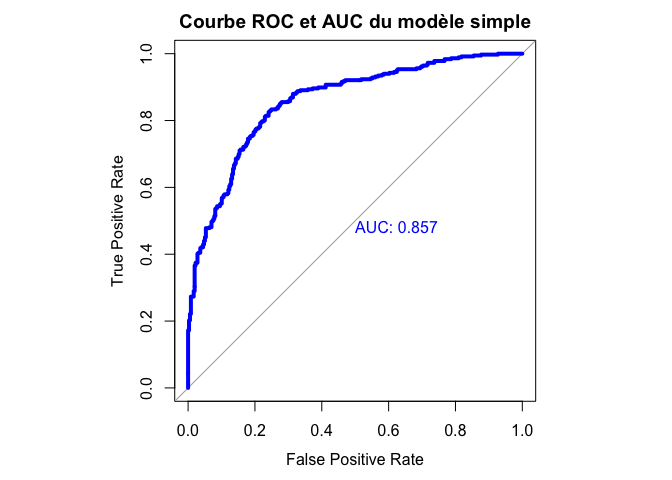

```
##
## Call:
## roc.default(response = DF$foyer, predictor = modele_12$fitted.values,     plot = TRUE, legacy.axes = TRUE, main = "Courbe ROC et AUC du modèle simple",     xlab = "False Positive Rate", ylab = "True Positive Rate",     col = "blue", lwd = 4, print.auc = TRUE)
##
## Data: modele_12$fitted.values in 357 controls (DF$foyer 0) < 366 cases (DF$foyer 1).
## Area under the curve: 0.857
```

```r
par(pty="s")
roc(DF$foyer,modele_12$fitted.values, plot=TRUE, legacy.axes=TRUE, main="Courbe ROC et AUC du modèle simple", xlab="False Positive Rate", ylab="True Positive Rate", col="blue", lwd=4, print.auc=TRUE)
```

## (3.2) MODÈLE COMPLEXE COURBE ROC ET AUC

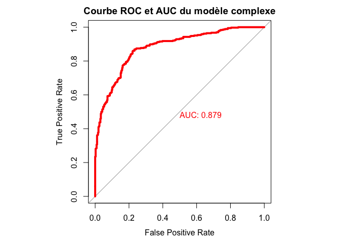

```
##
## Call:
## roc.default(response = DF$foyer, predictor = modele_step_AIC$fitted.values,     plot = TRUE, legacy.axes = TRUE, main = "Courbe ROC et AUC du modèle complexe",     xlab = "False Positive Rate", ylab = "True Positive Rate",     col = "Red", lwd = 4, print.auc = TRUE)
##
## Data: modele_step_AIC$fitted.values in 357 controls (DF$foyer 0) < 366 cases (DF$foyer 1).
## Area under the curve: 0.8793
```

```r
library(pROC)
par(pty="s")
roc(DF$foyer,modele_step_AIC$fitted.values, plot=TRUE, legacy.axes=TRUE, main="Courbe ROC et AUC du modèle complexe",xlab="False Positive Rate", ylab="True Positive Rate", col="Red", lwd=4, print.auc=TRUE)
```

## (3.3) COMPARAISON COURBE ROC ET AUC DES DEUX MODÈLES

```r
library(pROC)
par(pty="s")
roc(DF$foyer,modele_12$fitted.values, plot=TRUE, legacy.axes=TRUE, main="Comparaison des Courbes ROC et des AUC des modèles obtenus",xlab="False Positive Rate", ylab="True Positive Rate", col="blue", lwd=4, print.auc=TRUE)
```

```
##
## Call:
## roc.default(response = DF$foyer, predictor = modele_12$fitted.values,     plot = TRUE, legacy.axes = TRUE, main = "Comparaison des Courbes ROC et des AUC des modèles obtenus",     xlab = "False Positive Rate", ylab = "True Positive Rate",     col = "blue", lwd = 4, print.auc = TRUE)
##
## Data: modele_12$fitted.values in 357 controls (DF$foyer 0) < 366 cases (DF$foyer 1).
## Area under the curve: 0.857
```

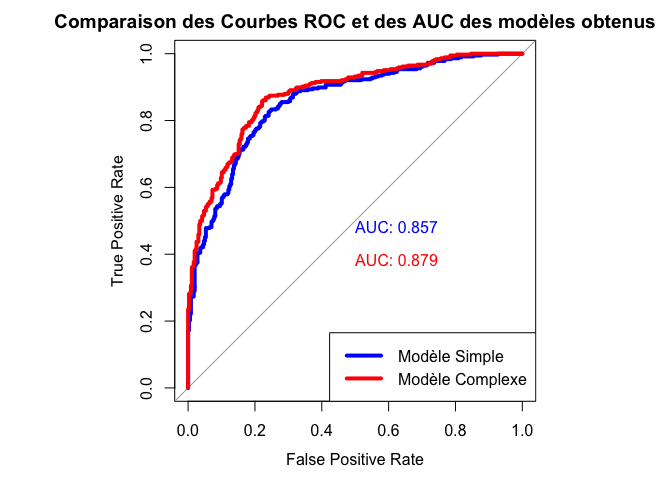

```r
plot.roc(DF$foyer,modele_step_AIC$fitted.values, col="Red", lwd=4, print.auc=TRUE, add=TRUE, print.auc.y=0.4)
legend("bottomright", legend = c("Modèle Simple","Modèle Complexe"),col = c("blue","Red"), lwd = 4)
```

# CONCLUSION

En somme, nous constatons que la courbe ROC du modèle complexe représentée en rouge vif est clairement plus éloignée de la diagonale comparativement à celle du modèle simple qui est elle représentée en bleu. Notamment, la valeur AUC du modèle complexe est plus élevée que celle du modèle simple (0.879 vs 0.857). De plus, le modèle complexe à un indice AIC inférieur à celui du modèle simple (679.36 vs 701.41) De ce fait, selon ces critères, nous considérons le modèle complexe comme étant le meilleur modèle.